# 02_Datawrangling

Chiara Draxler

6 1 2022

#Introduction for working code:

0. Download the Code from Github. The new downloaded folder hc_switch_cccu-main contains the R project, Rmd Code, created data frames, knitted Html Code, Figures as .pdf and.jpg, Preregistered synthetic Code, and a folder to store the downloaded RData called RData.

Name the folder appropriately (when downloading the code from GitHub the folder will be hc_switch_cccu-main).

1. Download data from https://www.icpsr.umich.edu/web/DSDR/studies/37067/datadocumentation

Attention! The downloaded project from GitHub does not contain any data files!

–> Click on Download, then select R, then follow the login –> store data in the folder specific to the R project in an extra sub-folder called RData (i.e., hc_switch_cccu-main - > RData). If you downloaded the code from GitHub, the RData folder will be already in the hc_switch_cccu-main projects folder.

–> Within the RData folder store data for wave 1 in DS0001, for wave 2 in DS0002 and so on (i.e., hc_switch_cccu-main - > RData -> DS0001 ). If you downloaded the code from GitHub, the relevant folders will be already there.

–> name the Rdata files according to the wave:

Wave 1: 37067-0001-Data (i.e., hc_switch_cccu-main - > RData -> DS0001 -> 37067-0001-Data.rda )

Wave 2: 37067-0002-Data (i.e., hc_switch_cccu-main - > RData -> DS0002 -> 37067-0002-Data.rda )

Wave 3: 37067-0003-Data (i.e., hc_switch_cccu-main - > RData -> DS0003 -> 37067-0003-Data.rda )

Wave 4: 37067-0004-Data (i.e., hc_switch_cccu-main - > RData -> DS0004 -> 37067-0004-Data.rda )

–> attention to the .rda ending when loading the data into R!

2. make sure to install all relevant packages before running the code!

All relevant packages and versions can be seen in the section “Analyses”

3. run the code according to the defined order beginning with 01_ (or 0 if you want to have a look at the synthetic data) and ending with 09_ so that all data frames are created appropriately
4. Run the Code :)

#1.Load Data

```r
load("cccu_complete.RData")
```

#2.Load Packages

```r
#loading dplyr
library("dplyr")
library(formr)
library("tidyverse")
```

#3. Selecting necessary columnsfor thesis’ question

```r
#Getting overview over columns
colnames(cccu_complete)
```

```
##   [1] "CASEID"                   "WEIGHT"
##   [3] "TM_START"                 "TM_FINISH"
##   [5] "DURATION"                 "INTVLANG"
##   [7] "MAINLANG"                 "DOV_Q26_1"
##   [9] "DOV_Q26_2"                "DOV_Q26_3"
##  [11] "DOV_Q26_4"                "DOV_Q26_5"
##  [13] "DOV_Q26_6"                "DOV_Q26_REFUSED"
##  [15] "EVERSEX"                  "TUBAL"
##  [17] "PSNIP"                    "NOWPREG"
##  [19] "MARRIED"                  "COHAB"
##  [21] "SEPARATE"                 "NEVMAR"
##  [23] "WIDOW"                    "DIVORCE"
##  [25] "XMAR"                     "STILLP"
##  [27] "DATING"                   "NDATING"
##  [29] "Q3B_A"                    "Q3B_B"
```

[output cut: 308 more lines]

List of necessary columns: CASEID WAVE WEIGHT AGE DEGREE POVRATE POVCAT TYPEINS MEDPROB GAPINS HLTHPROB AVOID FEELPG NBIRTHS BIRTH3MO PREG MONTHSA MONTHSB MONTHSC MOTNHSD1 MONTHSD3 MONTHSE1 MONTHSE3 YEARSA YEARSB YEARSC YEARSD1 YEARSD2 YEARSE1 YEARSE2 SEXSAT SEXMO NSEXMO RASAT1 RASAT2 RASAT3 RASAT4 RASAT5 RSATIS SATISBC PILL PATCH RING DEPO IUD IMPLANT YPILL YPATCH YRING YDEPO YIMPLANT YIUD MPILL MPATCH MRING MDEPO MIMPLANT MIUD Q23A_PILL Q23A_PATCH Q23A_RING Q23A_DEPO Q23A_IMPLANT Q23A_IUD TIMEUSE FREQBAR FREQBARB WITHDRAW VASECTOMY CONDOM NFP SPERM NOBARRIER XBARR DOV_Q26_1 DOV_Q26_2 DOV_Q26_3 DOV_Q26_4 DOV_Q26_5 DOV_Q26_6 DOV_Q26_REFUSED Time

```r
#Select variables

cccu_complete1 <- cccu_complete %>%
  select(
    CASEID,
    WAVE,
    EC,
    AGE,
    DEGREE,
    POVRATE,
    HHINC,
    MARSTAT,
    REGION,
    STATE,
    TYPEINS,
    EMPSTAT,
    RACETH,
    MEDPROB,
    GAPINS,
    HLTHPROB,
    AVOID,
    AVOID3,
    FEELPG,
    NBIRTHS,
    BIRTH3MO,
    PREG,
    CURRENT,
    Q3B_A,
    Q3B_B,
    Q3B_C,
    Q3B_D1,
    Q4_C,
    Q4_D1,
    MONTHSA,
    MONTHSB,
    MONTHSC,
    MONTHSD1,
    YEARSA,
    YEARSB,
    YEARSC,
    YEARSD1,
    SEXSAT,
    SEXMO,
    NSEXMO,
    starts_with("RSAT"),
    #includes RSATIS as overall measure for satisfaciton with barrier methods
    SATISBC,
    starts_with("Q23D"),
    HORMONAL,
    PILL,
    PATCH,
    RING,
    DEPO,
    IUD,
    IMPLANT,
    YPILL,
    YPATCH,
    YRING,
    YDEPO,
    YIMPLANT,
    YIUD,
    MPILL,
    MPATCH,
    MRING,
    MDEPO,
    MIMPLANT,
    MIUD,
    starts_with("Q23A_"),
    TIMEUSE,
    WITHDRAWR,
    VASECTOMY,
    CONDOMR,
    NFPR,
    SPERMR,
    NOBARRIER,
    XBARR,
    starts_with("DOV_Q26_"),
    SP1VAS,
    SP2VAS
  )

#double check column WAVE
table(cccu_complete1$WAVE)
```

```
##
##   t1   t2   t3   t4
## 4634 3207 2398 1842
```

#4. Variable Wrangling

##Variables for Exclusion ###EC (for exclusion)

```r
table(cccu_complete1$EC)
```

```
##
##   (-1) Refused         (0) No        (1) Yes  (3) Dont Know (4) Didnt care
##             31           5556             92              0              0
```

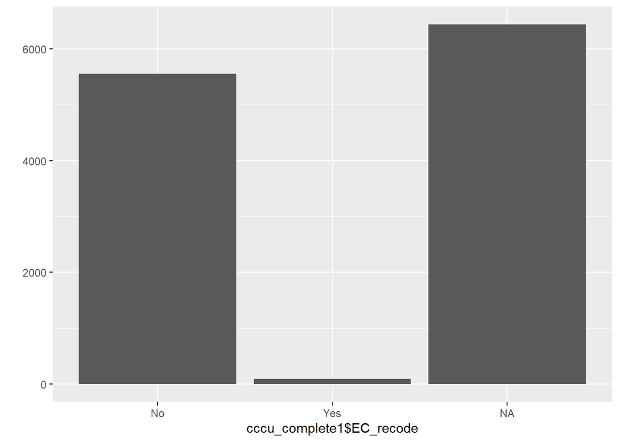

```r
cccu_complete1 <- cccu_complete1 %>%
  mutate(EC_recode = ifelse(EC == "(0) No", 0,
                            ifelse(EC == "(1) Yes", 1, NA)))



#factorize
cccu_complete1$EC_recode <-
  factor(cccu_complete1$EC_recode,
         levels = c(0, 1),
         labels = c("No", "Yes"))

qplot(cccu_complete1$EC_recode)
```

```r
table(cccu_complete1$EC_recode)
```

```
##
##   No  Yes
## 5556   92
```

```r
crosstabs( ~ is.na(EC) + WAVE, data = cccu_complete1)#item is missing at t1
```

```
##          WAVE
## is.na(EC)   t1   t2   t3   t4
##     FALSE    0 2479 1810 1390
##     TRUE  4634  728  588  452
```

##Variables for Sample Description ###Income (for descriptives)

```r
table(cccu_complete1$HHINC)
```

```
##
##            (-2) Not asked              (-1) refused     (01) Less than $5,000
##                         0                         0                       513
##     (02) $5,000 to $7,499     (03) $7,500 to $9,999   (04) $10,000 to $12,499
##                       281                       298                       339
##   (05) $12,500 to $14,999   (06) $15,000 to $19,999   (07) $20,000 to $24,999
##                       326                       532                       759
##   (08) $25,000 to $29,999   (09) $30,000 to $34,999   (10) $35,000 to $39,999
##                       856                       780                       778
##   (11) $40,000 to $49,999   (12) $50,000 to $59,999   (13) $60,000 to $74,999
##                      1358                      1075                      1132
##   (14) $75,000 to $84,999   (15) $85,000 to $99,999 (16) $100,000 to $124,999
##                       736                       800                       725
## (17) $125,000 to $149,999 (18) $150,000 to $174,999     (19) $175,000 or more
##                       316                       214                       263
```

```r
cccu_complete1 <- cccu_complete1 %>%
  mutate(
    Income = recode(
      HHINC,
      "(-2) Not asked"="NA",
      "(-1) refused"="NA",
      "(01) Less than $5,000" = "1",
      "(02) $5,000 to $7,499" = "2",
      "(03) $7,500 to $9,999" = "3",
      "(04) $10,000 to $12,499" = "4",
      "(05) $12,500 to $14,999" = "5",
      "(06) $15,000 to $19,999" = "6",
      "(07) $20,000 to $24,999" = "7",
      "(08) $25,000 to $29,999"= "8",
      "(09) $30,000 to $34,999"="9",
      "(10) $35,000 to $39,999"= "10",
      "(11) $40,000 to $49,999" = "11",
      "(12) $50,000 to $59,999"= "12",
      "(13) $60,000 to $74,999"= "13",
      "(14) $75,000 to $84,999"= "14",
      "(15) $85,000 to $99,999"= "15",
      "(16) $100,000 to $124,999"= "16",
      "(17) $125,000 to $149,999"= "17",
      "(18) $150,000 to $174,999"= "18",
      "(19) $175,000 or more"= "19",
))

table(cccu_complete1$Income)
```

```
##
##   NA    1    2    3    4    5    6    7    8    9   10   11   12   13   14   15
##    0  513  281  298  339  326  532  759  856  780  778 1358 1075 1132  736  800
##   16   17   18   19
##  725  316  214  263
```

```r
cccu_complete1$Income<-
  factor(
    cccu_complete1$Income,
    levels = c(1, 2, 3, 4, 5, 6, 7, 8, 9, 10, 11, 12, 13, 14,15,16,17,18,19),
    labels = c(
      "Less than $5,000",
"$5,000 to $7,499",
"$7,500 to $9,999",
"$10,000 to $12,499",
"$12,500 to $14,999",
"$15,000 to $19,999",
"$20,000 to $24,999",
"$25,000 to $29,999",
"$30,000 to $34,999",
"$35,000 to $39,999",
"$40,000 to $49,999",
"$50,000 to $59,999",
"$60,000 to $74,999",
"$75,000 to $84,999",
"$85,000 to $99,999",
"$100,000 to $124,999",
"$125,000 to $149,999",
"$150,000 to $174,999",
"$175,000 or more"
  ))
```

###Ethnicity

```r
table(cccu_complete1$RACETH)
```

```
##
##             (-2) Not asked               (-1) refused
##                          0                          0
##    (1) White, Non-Hispanic    (2) Black, Non-Hispanic
##                       7895                       1118
##    (3) Other, Non-Hispanic               (4) Hispanic
##                        674                       2067
## (5) 2+ Races, Non-Hispanic
##                        327
```

```r
cccu_complete1 <- cccu_complete1 %>%
  mutate(
    Ethnicity = recode(
      RACETH,
      "(-2) Not asked"= "NA",
      "(-1) refused"= "NA",
      "(1) White, Non-Hispanic"="1",
      "(2) Black, Non-Hispanic"="2",
      "(3) Other, Non-Hispanic"="3",
      "(4) Hispanic"="4",
      "(5) 2+ Races, Non-Hispanic"="5"
    ))


cccu_complete1$Ethnicity<-
  factor(
    cccu_complete1$Ethnicity,
    levels = c(1, 2, 3, 4, 5),
    labels = c(
      "White, Non-Hispanic",
      "Black, Non-Hispanic",
      "Other, Non-Hispanic",
      "Hispanic",
      "2+ Races, Non-Hispanic"))

table(cccu_complete1$Ethnicity)
```

```
##
##    White, Non-Hispanic    Black, Non-Hispanic    Other, Non-Hispanic
##                   7895                   1118                    674
##               Hispanic 2+ Races, Non-Hispanic
##                   2067                    327
```

###Employment Status

```r
table(cccu_complete1$EMPSTAT)
```

```
##
##                                   (-2) Not asked
##                                                0
##                                     (-1) refused
##                                                0
##                 (1) Working - as a paid employee
##                                             7347
##                      (2) Working - self-employed
##                                              593
## (3) Not working - on temporary layoff from a job
##                                              117
##               (4) Not working - looking for work
##                                             1532
##                        (5) Not working - retired
##                                                6
##                       (6) Not working - disabled
##                                              205
##                          (7) Not working - other
##                                             2281
```

```r
cccu_complete1 <- cccu_complete1 %>%
  mutate(
    Employment_status = recode(
      EMPSTAT,
      "(-2) Not asked"="NA",
      "(-1) refused"="NA",
      "(1) Working - as a paid employee"="1",
      "(2) Working - self-employed"="2",
      "(3) Not working - on temporary layoff from a job"="3",
      "(4) Not working - looking for work"="4",
      "(5) Not working - retired"="5",
      "(6) Not working - disabled"="6",
      "(7) Not working - other"="7"
))

cccu_complete1$Employment_status<-
  factor(
    cccu_complete1$Employment_status,
    levels = c(1, 2, 3, 4, 5,6,7),
    labels = c("Working - as a paid employee",
               "Working - self-employed",
               "Not working - on temporary layoff from a job",
               "Not working - looking for work",
               "Not working - retired",
               "Not working - disabled",
               "Not working - other"))

table(cccu_complete1$Employment_status)
```

```
##
##                 Working - as a paid employee
##                                         7347
##                      Working - self-employed
##                                          593
## Not working - on temporary layoff from a job
##                                          117
##               Not working - looking for work
##                                         1532
##                        Not working - retired
##                                            6
##                       Not working - disabled
##                                          205
##                          Not working - other
##                                         2281
```

###Martial Status

```r
table(cccu_complete1$MARSTAT)
```

```
##
##          (-2) Not asked            (-1) refused             (1) Married
##                       0                       0                    5536
##             (2) Widowed            (3) Divorced           (4) Separated
##                      18                     376                     139
##       (5) Never married (6) Living with partner
##                    3875                    2137
```

###Region

```r
table(cccu_complete1$REGION)
```

```
##
## (-2) Not asked   (-1) refused  (1) Northeast    (2) Midwest      (3) South
##              0              0           1942           3170           3751
##       (4) West
##           3218
```

```r
cccu_complete1 <- cccu_complete1 %>%
  mutate(
    Region_recode = recode(
      REGION,
      "(-2) Not asked"="NA",
      "(-1) refused"="NA",
      "(1) Northeast"="1",
      "(2) Midwest"="2",
      "(3) South"="3",
      "(4) West"="4"
    ))

cccu_complete1$Region_recode<-
  factor(
    cccu_complete1$Region_recode,
    levels = c(1, 2, 3, 4),
    labels = c("Northeast", "Midwest", "South", "West"))

table(cccu_complete1$Region_recode)
```

```
##
## Northeast   Midwest     South      West
##      1942      3170      3751      3218
```

###State

```r
table(cccu_complete1$STATE)
```

```
##
## (-2) Not asked   (-1) refused        (11) me        (12) nh        (13) vt
##              0              0             42             44             32
##        (14) ma        (15) ri        (16) ct        (21) ny        (22) nj
##            296             45             96            644            202
##        (23) pa        (31) oh        (32) in        (33) il        (34) mi
##            541            510            265            504            450
##        (35) wi        (41) mn        (42) ia        (43) mo        (44) nd
##            368            309            199            285             32
##        (45) sd        (46) ne        (47) ks        (51) de        (52) md
##             36             92            120             22            152
##        (53) dc        (54) va        (55) wv        (56) nc        (57) sc
##             34            249             54            423            111
##        (58) ga        (59) fl        (61) ky        (62) tn        (63) al
##            346            640            173            194            149
##        (64) ms        (71) ar        (72) la        (73) ok        (74) tx
##             73             99            130             99            803
##        (81) mt        (82) id        (83) wy        (84) co        (85) nm
##             58             87             12            183             91
##        (86) az        (87) ut        (88) nv        (91) wa        (92) or
##            232            204             99            342            259
##        (93) ca        (94) ak        (95) hi        (96) as        (97) gu
##           1608             19             24              0              0
##        (98) pr        (99) vi
##              0              0
```

```r
cccu_complete1$STATE<-as.character(cccu_complete1$STATE)

cccu_complete1 <- cccu_complete1 %>%
  mutate(
    state_recode = recode(
      STATE,
      "(11) me"="1",
"(12) nh"="2",
"(13) vt"="3",
"(14) ma"="4",
"(15) ri"="5",
"(16) ct"="6",
"(21) ny"="7",
"(22) nj"="8",
"(23) pa"="9",
"(31) oh" ="10",
"(32) in"="11",
"(33) il" ="12",
"(34) mi" ="13",
"(35) wi" ="14",
"(41) mn" ="15",
"(42) ia" ="16",
"(43) mo" ="17",
"(44) nd" ="18",
"(45) sd"="19",
"(46) ne" ="20",
"(47) ks"="21",
"(51) de" ="22",
"(52) md" ="23",
"(53) dc" ="24",
"(54) va" ="25",
"(55) wv" ="26",
"(56) nc"="27",
"(57) sc" ="28",
"(58) ga" ="29",
"(59) fl" ="30",
"(61) ky" ="31",
"(62) tn"="32",
"(63) al" ="33",
"(64) ms"="34",
"(71) ar" ="35",
"(72) la" ="36",
"(73) ok" ="37",
"(74) tx" ="38",
"(81) mt" ="39",
"(82) id" ="40",
"(83) wy"="41",
"(84) co" ="42",
"(85) nm" ="43",
"(86) az"="44",
"(87) ut" ="45",
"(88) nv" ="46",
"(91) wa" ="47",
"(92) or" ="48",
"(93) ca" ="49",
"(94) ak"="50",
"(95) hi"="51"))

table(cccu_complete1$state_recode)
```

```
##
##    1   10   11   12   13   14   15   16   17   18   19    2   20   21   22   23
##   42  510  265  504  450  368  309  199  285   32   36   44   92  120   22  152
##   24   25   26   27   28   29    3   30   31   32   33   34   35   36   37   38
##   34  249   54  423  111  346   32  640  173  194  149   73   99  130   99  803
##   39    4   40   41   42   43   44   45   46   47   48   49    5   50   51    6
##   58  296   87   12  183   91  232  204   99  342  259 1608   45   19   24   96
##    7    8    9
##  644  202  541
```

```r
cccu_complete1$state_recode<-
  factor(
    cccu_complete1$state_recode,
    levels = c(1:51),
    labels = c("Maine", "New Hampshire", "Vermont",
               "Massachusetts", "Rhode Island", "Conneticut",
               "New York", "New Jersey", "Pennsylvania",
               "Ohio", "Indiana", "Illinois", "Michigan",
               "Wisconsin", "Minnesota", "Iowa",
               "Missouri", "North Dakota", "South Dakota",
               "Nevada", "Kansas", "Delaware",
               "Maryland", "D.C.", "Virginia", "West Virginia",
               "North Carolina", "South Carolina", "Georgia",
               "Florida", "Kentucky", "Tennessee", "Alabama",
               "Mississippi", "Arkansas", "Louisiana",
               "Oklahoma", "Texas", "Montana", "Idaho",
               "Wyoming", "Colorado", "New Mexico", "Arizona",
               "Utah", "Nevada", "Washington", "Oregon",
               "California", "Alaska", "Hawaii"))

table(cccu_complete1$state_recode)
```

```
##
##          Maine  New Hampshire        Vermont  Massachusetts   Rhode Island
##             42             44             32            296             45
##     Conneticut       New York     New Jersey   Pennsylvania           Ohio
##             96            644            202            541            510
##        Indiana       Illinois       Michigan      Wisconsin      Minnesota
##            265            504            450            368            309
##           Iowa       Missouri   North Dakota   South Dakota         Nevada
##            199            285             32             36            191
##         Kansas       Delaware       Maryland           D.C.       Virginia
##            120             22            152             34            249
##  West Virginia North Carolina South Carolina        Georgia        Florida
##             54            423            111            346            640
##       Kentucky      Tennessee        Alabama    Mississippi       Arkansas
##            173            194            149             73             99
##      Louisiana       Oklahoma          Texas        Montana          Idaho
##            130             99            803             58             87
##        Wyoming       Colorado     New Mexico        Arizona           Utah
##             12            183             91            232            204
##     Washington         Oregon     California         Alaska         Hawaii
##            342            259           1608             19             24
```

##4.0 Wave

```r
cccu_complete1$WAVE <- as.factor(cccu_complete1$WAVE)

class(cccu_complete1$WAVE)
```

```
## [1] "factor"
```

##4.1 Degree

```r
#Overview over Column
table(cccu_complete1$DEGREE)
```

```
##
##                                                          (-2) Not asked
##                                                                       0
##                                                            (-1) refused
##                                                                       0
##                                                (01) No formal education
##                                                                       9
##                                        (02) 1st, 2nd, 3rd, or 4th grade
##                                                                       7
##                                                   (03) 5th or 6th grade
##                                                                      61
##                                                   (04) 7th or 8th grade
##                                                                      52
##                                                          (05) 9th grade
##                                                                      85
##                                                         (06) 10th grade
##                                                                     108
##                                                         (07) 11th grade
##                                                                     100
##                                              (08) 12th grade NO DIPLOMA
##                                                                     138
## (09) HIGH SCHOOL GRADUATE - high school DIPLOMA or the equivalent (GED)
##                                                                    1695
##                                            (10) Some college, no degree
##                                                                    3064
##                                                   (11) Associate degree
##                                                                    1320
##                                                   (12) Bachelors degree
##                                                                    3776
##                                                     (13) Masters degree
##                                                                    1342
##                                   (14) Professional or Doctorate degree
##                                                                     324
```

Values are: (-2) Not asked (-1) refused (01) No formal education (02) 1st, 2nd, 3rd, or 4th grade (03) 5th or 6th grade (04) 7th or 8th grade (05) 9th grade (06) 10th grade (07) 11th grade (08) 12th grade NO DIPLOMA (09) HIGH SCHOOL GRADUATE - high school DIPLOMA or the equivalent (GED) (10) Some college, no degree (11) Associate degree (12) Bachelors degree (13) Masters degree (14) Professional or Doctorate degree

we want to keep all numbers (not necessary to summarize in one category) and there is no category twice (with different number), we can simply recode it

```r
cccu_complete1 <- cccu_complete1 %>%
  mutate(
    DEGREE_recode = recode(
      DEGREE,
      "(-2) Not asked"="NA",
                                "(-1) refused"="NA",
                                "(01) No formal education" ="1",
                                "(02) 1st, 2nd, 3rd, or 4th grade" = "2",
                                "(03) 5th or 6th grade" = "3",
                                "(04) 7th or 8th grade" = "4",
                                "(05) 9th grade" = "5",
                                "(06) 10th grade" = "6",
                                "(07) 11th grade" = "7",
                                "(08) 12th grade NO DIPLOMA" = "8",
                                "(09) HIGH SCHOOL GRADUATE - high school DIPLOMA or the equivalent (GED)" = "9",
                                "(10) Some college, no degree" = "10",
                                "(11) Associate degree" = "11",
                                "(12) Bachelors degree" = "12",
                                "(13) Masters degree" = "13",
                                "(14) Professional or Doctorate degree" = "14"
    ))

table(cccu_complete1$DEGREE)
```

```
##
##                                                          (-2) Not asked
##                                                                       0
##                                                            (-1) refused
##                                                                       0
##                                                (01) No formal education
##                                                                       9
##                                        (02) 1st, 2nd, 3rd, or 4th grade
##                                                                       7
##                                                   (03) 5th or 6th grade
##                                                                      61
##                                                   (04) 7th or 8th grade
##                                                                      52
##                                                          (05) 9th grade
##                                                                      85
##                                                         (06) 10th grade
##                                                                     108
##                                                         (07) 11th grade
##                                                                     100
##                                              (08) 12th grade NO DIPLOMA
##                                                                     138
## (09) HIGH SCHOOL GRADUATE - high school DIPLOMA or the equivalent (GED)
##                                                                    1695
##                                            (10) Some college, no degree
##                                                                    3064
##                                                   (11) Associate degree
##                                                                    1320
##                                                   (12) Bachelors degree
##                                                                    3776
##                                                     (13) Masters degree
##                                                                    1342
##                                   (14) Professional or Doctorate degree
##                                                                     324
```

```r
table(cccu_complete1$DEGREE_recode)
```

```
##
##   NA    1    2    3    4    5    6    7    8    9   10   11   12   13   14
##    0    9    7   61   52   85  108  100  138 1695 3064 1320 3776 1342  324
```

```r
#Factorizing it with levels
cccu_complete1$DEGREE_recode<-
factor(cccu_complete1$DEGREE_recode, levels = c(1,2,3,4,5,6,7,8,9,10,11,12,13,14), labels = c("no formal education", "1st to 4th grade", "5th/6th grade", "7th/8th grade", "9th grade", "10th grade", "11th grade", "12th grade / no diploma", "high school diploma or equivalent", "some college, no degree", "associate degree", "bachelors degree", "masters degree", "professional or doctoral degree"))

crosstabs( ~ DEGREE_recode + WAVE, data = cccu_complete1)
```

```
##                                    WAVE
## DEGREE_recode                         t1   t2   t3   t4
##   no formal education                  6    3    0    0
##   1st to 4th grade                     3    2    1    1
##   5th/6th grade                       23   17   13    8
##   7th/8th grade                       26   15    7    4
##   9th grade                           39   25   13    8
##   10th grade                          40   28   23   17
##   11th grade                          41   26   21   12
##   12th grade / no diploma             59   37   25   17
##   high school diploma or equivalent  718  439  312  226
##   some college, no degree           1253  801  580  430
##   associate degree                   507  348  268  197
##   bachelors degree                  1330 1019  790  637
##   masters degree                     471  363  277  231
##   professional or doctoral degree    118   84   68   54
```

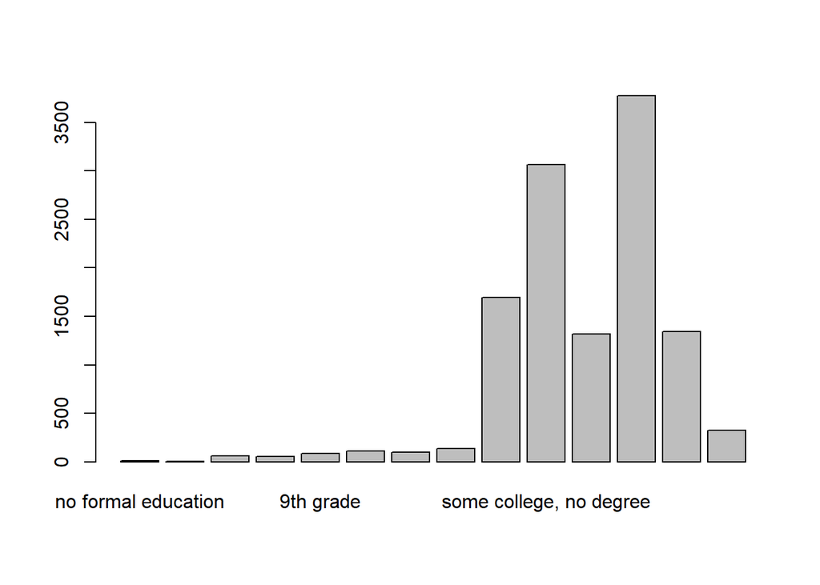

```r
plot(cccu_complete1$DEGREE_recode)
```

## 4.2 Age

```r
#overview

table(cccu_complete1$AGE)
```

```
##
##  18  19  20  21  22  23  24  25  26  27  28  29  30  31  32  33  34  35  36  37
##  66 194 290 468 554 721 872 949 791 779 915 851 583 501 433 510 488 494 462 396
##  38  39
## 407 357
```

```r
#as.numeric
cccu_complete1$AGE <- as.numeric(cccu_complete1$AGE)

class(cccu_complete1$AGE)
```

```
## [1] "numeric"
```

```r
crosstabs( ~ AGE + WAVE, data = cccu_complete1)
```

```
##     WAVE
## AGE   t1  t2  t3  t4
##   18  35  15  10   6
##   19  82  51  35  26
##   20 114  75  57  44
##   21 184 126  89  69
##   22 221 148 107  78
##   23 269 193 147 112
##   24 334 232 172 134
##   25 375 242 185 147
##   26 307 207 155 122
##   27 306 197 154 122
##   28 358 240 179 138
##   29 349 232 160 110
##   30 217 154 121  91
##   31 180 130 106  85
##   32 157 115  92  69
##   33 190 142 102  76
##   34 187 134  93  74
##   35 175 133 103  83
##   36 171 127  94  70
##   37 137 108  83  68
##   38 154 110  83  60
##   39 132  96  71  58
```

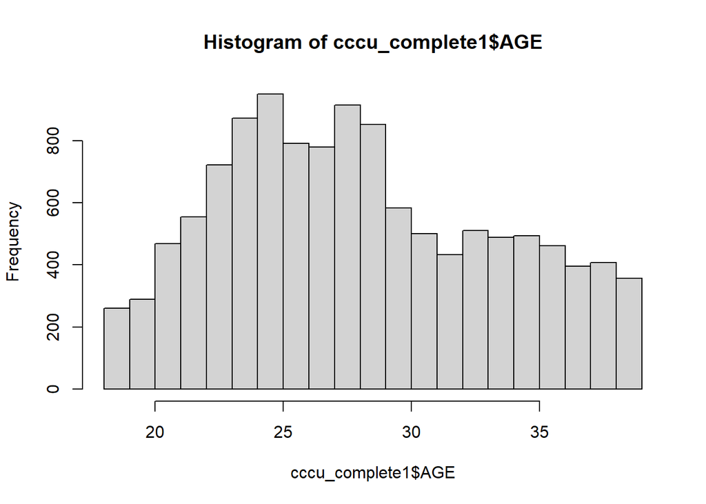

```r
hist(cccu_complete1$AGE)
```

##4.3 POVERTY: POVRATE

```r
table(cccu_complete1$POVRATE)
```

```
##
##   13   14   16   18   19   20   21   22   23   25   26   27   28   29   30   32
##    3    8   29   22   21   12   38   46   23    3  119   50    9    5    1  109
##   33   35   36   37   38   39   40   41   42   44   45   46   48   49   50   51
##   87    5   20   32   29    9   28   41   14   48   59   27   23   31   13   15
##   53   54   55   56   57   58   59   60   63   64   65   69   70   71   72   73
##    1   30   13   54   13  121   42   28   24    7   23   10   37   19   35   54
##   74   76   77   78   79   82   83   84   86   87   88   89   90   91   92   93
##   89   70    1   17    4   59   39    3    2   23    1   46   59   26   48    6
##   94   95   96   98  100  101  102  103  105  106  107  108  113  114  115  116
##    1    4   60   69   29    8   24   21   21    2    5    1   71    2   68   52
##  117  118  119  120  121  123  126  128  129  130  136  138  139  141  142  144
##   60  126   60   63    8   24    6    2    6    1   39   76   40  169   26   83
##  145  146  149  152  154  157  158  159  163  166  167  170  174  177  178  182
##  120    1   96   25    4   34    2   73  109   63   42   56   19  121   10   95
```

[output cut: 20 more lines]

```r
cccu_complete1$POVRATE <- as.numeric(cccu_complete1$POVRATE)

class(cccu_complete1$POVRATE)
```

```
## [1] "numeric"
```

```r
crosstabs( ~ POVRATE + WAVE, data = cccu_complete1)
```

```
##        WAVE
## POVRATE   t1   t2   t3   t4
##    13      2    1    0    0
##    14      5    2    1    0
##    16     15    9    5    0
##    18      3   13    6    0
##    19     21    0    0    0
##    20      5    4    3    0
##    21      0   25   13    0
##    22     44    1    1    0
##    23     11    8    4    0
##    25      1    1    1    0
##    26     56   34   29    0
##    27     27   12   11    0
##    28      4    3    2    0
```

[output cut: 246 more lines]

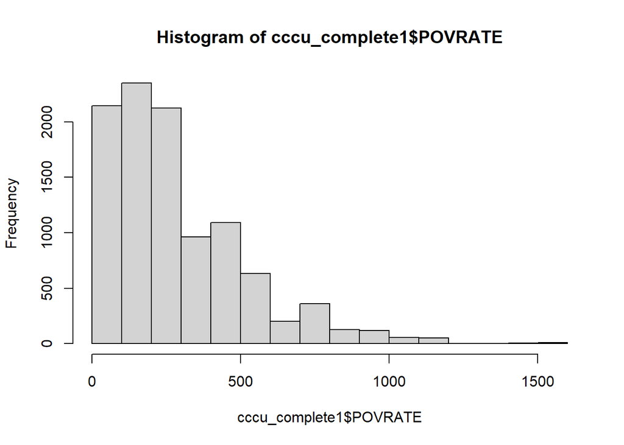

```r
hist(cccu_complete1$POVRATE)
```

##4.4 TYPE of INSURANCE

```r
#Overview
table(cccu_complete1$TYPEINS)
```

```
##
##                                                                                                                 (-1) Refused
##                                                                                                                            0
##                       (1) Private health insurance I get through my job or school, a family member or that I pay for myself.
##                                                                                                                         6720
##                              (2) (Medicaid Program - BASED ON PPSTATEN) or some other government-sponsored health insurance.
##                                                                                                                          759
##                                                                                      (3) Some other type of health insurance
##                                                                                                                           82
##                                                                                           (4) I don't have health insurance.
##                                                                                                                         2012
##                                                       (2) {#\\.POV_Q38} or some other government-sponsored health insurance.
##                                                                                                                          785
## (0) Insurance obtained through a health insurance marketplace or exchange, such as www.healthcare.gov or {state-specific mar
##                                                                                                                          119
##                  (1) Private health insurance that I get through my job or school, a family member or that I pay for myself.
##                                                                                                                         1255
##                                                           (2) {PPSTATE} or some other government-sponsored health insurance.
##                                                                                                                          243
##        (5) Insurance obtained through a health insurance marketplace or exchange, such as www.healthcare.gov{#POV_PROGNAME_Q
##                                                                                                                            0
```

```r
cccu_complete1 <- cccu_complete1 %>%
  mutate(
    TYPEINS_recode = recode(
      TYPEINS,
      "(-1) Refused" = "NA",
      "(1) Private health insurance I get through my job or school, a family member or that I pay for myself." =
        "1",
      "(2) (Medicaid Program - BASED ON PPSTATEN) or some other government-sponsored health insurance." = "1",
      "(3) Some other type of health insurance" = "1",
      "(4) I don't have health insurance." = "0",
      "(2) {#\\.POV_Q38} or some other government-sponsored health insurance." = "1",
      "(0) Insurance obtained through a health insurance marketplace or exchange, such as www.healthcare.gov or {state-specific mar" = "1",
      "(1) Private health insurance that I get through my job or school, a family member or that I pay for myself." = "1",
      "(2) {PPSTATE} or some other government-sponsored health insurance." = "1",
      "(5) Insurance obtained through a health insurance marketplace or exchange, such as www.healthcare.gov{#POV_PROGNAME_Q" = "1"
    )
  )

table(cccu_complete1$TYPEINS_recode)
```

```
##
##   NA    1    0
##    0 9963 2012
```

```r
sum(is.na(cccu_complete1$TYPEINS))
```

```
## [1] 106
```

```r
#Factorize
cccu_complete1$TYPEINS_recode <-
  factor(
    cccu_complete1$TYPEINS_recode,
    levels = c(0, 1),
    labels = c("No", "Yes")
  )
table(cccu_complete1$TYPEINS_recode)
```

```
##
##   No  Yes
## 2012 9963
```

```r
crosstabs( ~ TYPEINS + WAVE, data = cccu_complete1)
```

```
##                                                                                                                               WAVE
## TYPEINS                                                                                                                          t1
##   (-1) Refused                                                                                                                    0
##   (1) Private health insurance I get through my job or school, a family member or that I pay for myself.                       2951
##   (2) (Medicaid Program - BASED ON PPSTATEN) or some other government-sponsored health insurance.                               759
##   (3) Some other type of health insurance                                                                                        42
##   (4) I don't have health insurance.                                                                                            841
##   (2) {#\\.POV_Q38} or some other government-sponsored health insurance.                                                          0
##   (0) Insurance obtained through a health insurance marketplace or exchange, such as www.healthcare.gov or {state-specific mar    0
##   (1) Private health insurance that I get through my job or school, a family member or that I pay for myself.                     0
##   (2) {PPSTATE} or some other government-sponsored health insurance.                                                              0
##   (5) Insurance obtained through a health insurance marketplace or exchange, such as www.healthcare.gov{#POV_PROGNAME_Q           0
##                                                                                                                               WAVE
## TYPEINS                                                                                                                          t2
##   (-1) Refused                                                                                                                    0
##   (1) Private health insurance I get through my job or school, a family member or that I pay for myself.                       2119
##   (2) (Medicaid Program - BASED ON PPSTATEN) or some other government-sponsored health insurance.                                 0
##   (3) Some other type of health insurance                                                                                        22
##   (4) I don't have health insurance.                                                                                            570
##   (2) {#\\.POV_Q38} or some other government-sponsored health insurance.                                                        467
##   (0) Insurance obtained through a health insurance marketplace or exchange, such as www.healthcare.gov or {state-specific mar    0
##   (1) Private health insurance that I get through my job or school, a family member or that I pay for myself.                     0
##   (2) {PPSTATE} or some other government-sponsored health insurance.                                                              0
##   (5) Insurance obtained through a health insurance marketplace or exchange, such as www.healthcare.gov{#POV_PROGNAME_Q           0
##                                                                                                                               WAVE
## TYPEINS                                                                                                                          t3
##   (-1) Refused                                                                                                                    0
##   (1) Private health insurance I get through my job or school, a family member or that I pay for myself.                       1650
##   (2) (Medicaid Program - BASED ON PPSTATEN) or some other government-sponsored health insurance.                                 0
##   (3) Some other type of health insurance                                                                                        11
##   (4) I don't have health insurance.                                                                                            401
##   (2) {#\\.POV_Q38} or some other government-sponsored health insurance.                                                        318
```

[output cut: 16 more lines]

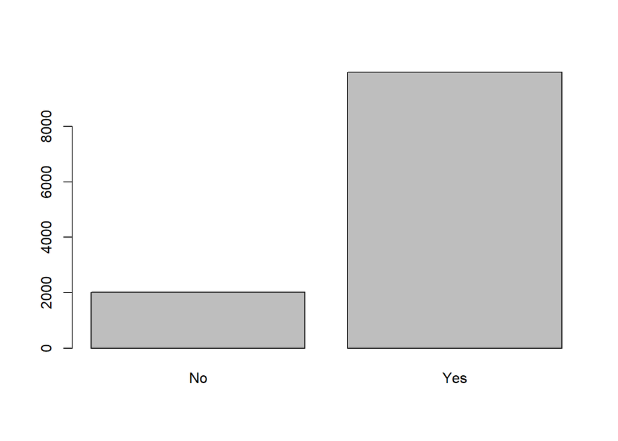

```r
plot(cccu_complete1$TYPEINS_recode)
```

##4.5 MEDICAL PROBLEMS

```r
table(cccu_complete1$MEDPROB)
```

```
##
##  (0) No (1) Yes
##   10948    1133
```

```r
crosstabs( ~ MEDPROB + WAVE, data = cccu_complete1)
```

```
##          WAVE
## MEDPROB     t1   t2   t3   t4
##   (0) No  4227 2906 2146 1669
##   (1) Yes  407  301  252  173
```

```r
cccu_complete1 <- cccu_complete1 %>%
  mutate(MEDPROB_recode = recode(MEDPROB,
                                 "(0) No" = "0",
                                 "(1) Yes" = "1"))



#factorize
cccu_complete1$MEDPROB_recode <-
  factor(
    cccu_complete1$MEDPROB_recode,
    levels = c(0, 1),
    labels = c("No", "Yes")
  )
table(cccu_complete1$MEDPROB_recode)
```

```
##
##    No   Yes
## 10948  1133
```

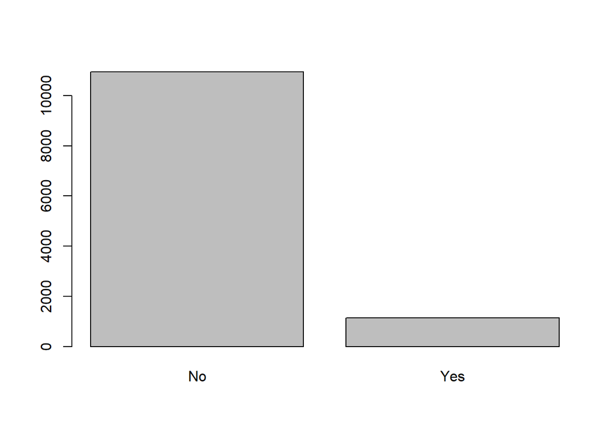

```r
plot(cccu_complete1$MEDPROB_recode)
```

##4.6 GAPS in INSURANCE

```r
#overview
table(cccu_complete1$GAPINS)
```

```
##
##  (0) no (1) yes
##    9371    2604
```

```r
crosstabs( ~ GAPINS + WAVE, data = cccu_complete1)
```

```
##          WAVE
## GAPINS      t1   t2   t3   t4
##   (0) no  3539 2470 1878 1484
##   (1) yes 1054  708  502  340
```

```r
#recode
cccu_complete1 <- cccu_complete1 %>%
  mutate(GAPINS_recode = recode(GAPINS,
                                "(0) no" = "0",
                                "(1) yes" = "1"))
#control
table(cccu_complete1$GAPINS_recode)
```

```
##
##    0    1
## 9371 2604
```

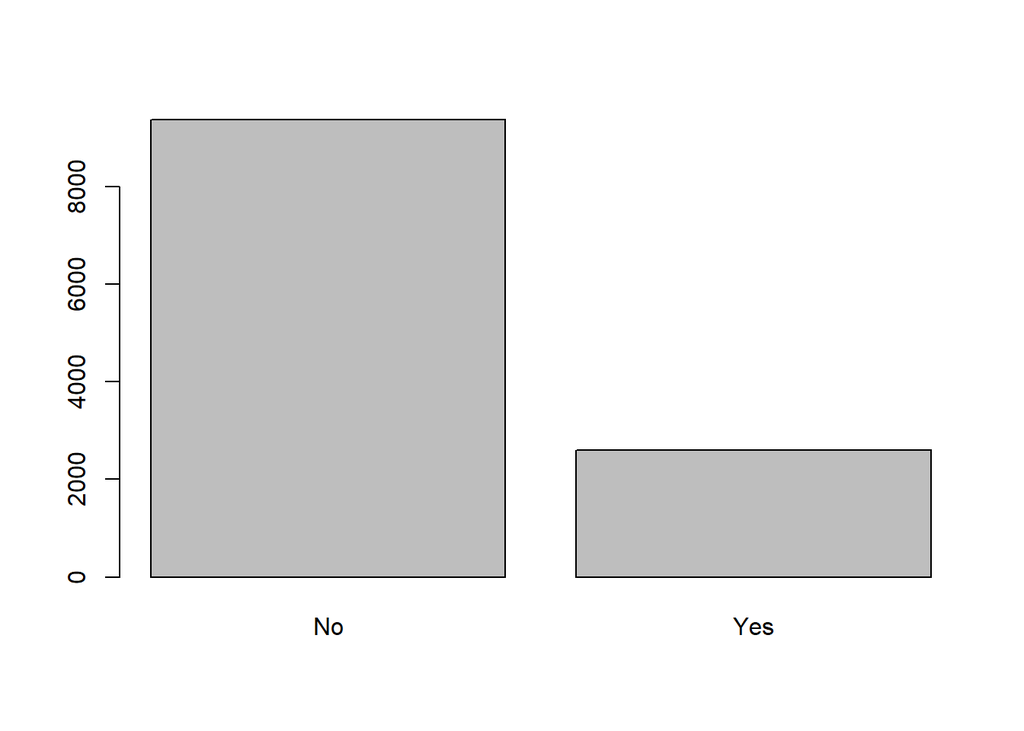

```r
#factorize
cccu_complete1$GAPINS_recode <-
  factor(
    cccu_complete1$GAPINS_recode,
    levels = c(0, 1),
    labels = c("No", "Yes")
  )

plot(cccu_complete1$GAPINS_recode)
```

##4.7 HEALTH PROBLEMS

```r
#overview
table(cccu_complete1$HLTHPROB)
```

```
##
##   (-1) Refused         (0) No        (1) Yes  (3) Dont Know (4) Didnt care
##              0           3552            816            239              0
```

```r
crosstabs( ~ HLTHPROB + WAVE, data = cccu_complete1)
```

```
##                 WAVE
## HLTHPROB           t1   t2   t3   t4
##   (-1) Refused      0    0    0    0
##   (0) No         3552    0    0    0
##   (1) Yes         816    0    0    0
##   (3) Dont Know   239    0    0    0
##   (4) Didnt care    0    0    0    0
```

Recoding values

```r
#Recoding
cccu_complete1 <- cccu_complete1 %>%
  mutate(
    HLTHPROB_recode = recode(
      HLTHPROB,
      "(-1) Refused" = "NA",
      "(0) No" = "0",
      "(1) Yes" = "1",
      "(3) Dont Know" = "NA",
      "(4) Didnt care" = "NA"
    ))

table(cccu_complete1$HLTHPROB_recode)
```

```
##
##   NA    0    1
##  239 3552  816
```

```r
#factorize
cccu_complete1$HLTHPROB_recode <-
  factor(
    cccu_complete1$HLTHPROB_recode,
    levels = c(0, 1),
    labels = c("No", "Yes")
  )

sum(is.na(cccu_complete1$HLTHPROB_recode))
```

```
## [1] 7713
```

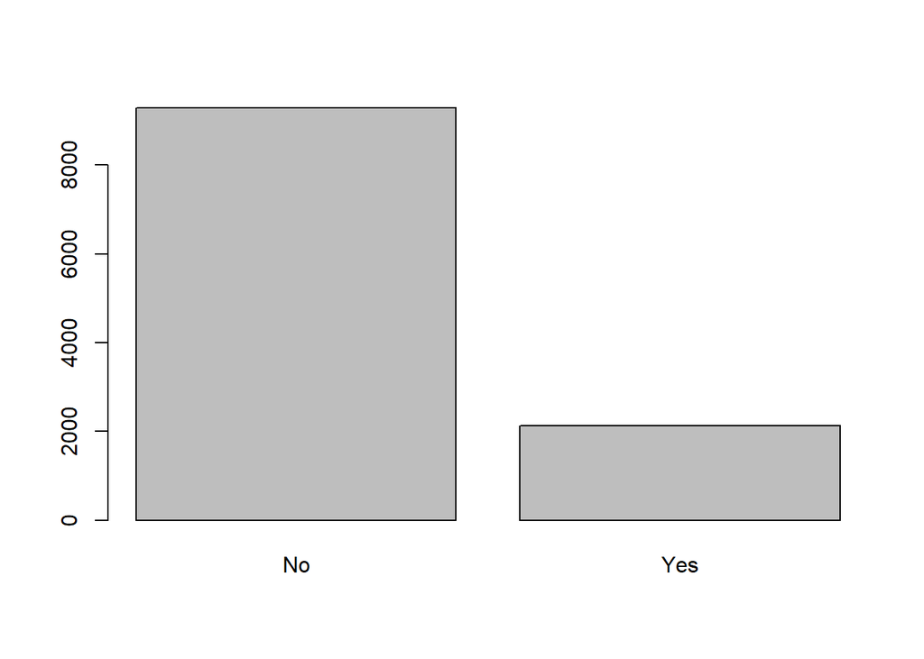

```r
#fill for each wave after t1 (for t2,t3,t4)
cccu_complete1 = cccu_complete1 %>%
  group_by(CASEID) %>%
  fill(HLTHPROB_recode)

plot(cccu_complete1$HLTHPROB_recode)
```

##4.8 Avoid Pregnancy

```r
#overview
table(cccu_complete1$AVOID)
```

```
##
##                                  (-1) Refused
##                                             0
## (1) Not at all important to avoid pregnancy 1
##                                          1254
##                                         (2) 2
##                                           388
##                                         (3) 3
##                                           734
##                                         (4) 4
##                                          1062
##                                         (5) 5
##                                          1315
##       (6) Very important to avoid pregnancy 6
##                                          4598
```

```r
table(cccu_complete1$AVOID3)
```

```
##
##                                  (-1) Refused
##                                             0
## (1) Not at all important to avoid pregnancy 1
##                                           318
##                                         (2) 2
##                                           101
##                                         (3) 3
##                                           172
##                                         (4) 4
##                                           234
##                                         (5) 5
##                                           321
##       (6) Very important to avoid pregnancy 6
##                                          1090
```

```r
table(is.na(cccu_complete1$AVOID))
```

```
##
## FALSE  TRUE
##  9351  2730
```

```r
crosstabs( ~ AVOID + WAVE, data = cccu_complete1)
```

```
##                                                WAVE
## AVOID                                             t1   t2   t3   t4
##   (-1) Refused                                     0    0    0    0
##   (1) Not at all important to avoid pregnancy 1  614  409    0  231
##   (2) 2                                          180  130    0   78
##   (3) 3                                          372  235    0  127
##   (4) 4                                          521  338    0  203
##   (5) 5                                          649  436    0  230
##   (6) Very important to avoid pregnancy 6       2270 1476    0  852
```

```r
crosstabs( ~ AVOID3 + WAVE, data = cccu_complete1)
```

```
##                                                WAVE
## AVOID3                                            t1   t2   t3   t4
##   (-1) Refused                                     0    0    0    0
##   (1) Not at all important to avoid pregnancy 1    0    0  318    0
##   (2) 2                                            0    0  101    0
##   (3) 3                                            0    0  172    0
##   (4) 4                                            0    0  234    0
##   (5) 5                                            0    0  321    0
##   (6) Very important to avoid pregnancy 6          0    0 1090    0
```

```r
crosstabs( ~ is.na(AVOID) + WAVE, data = cccu_complete1)
```

```
##             WAVE
## is.na(AVOID)   t1   t2   t3   t4
##        FALSE 4606 3024    0 1721
##        TRUE    28  183 2398  121
```

```r
crosstabs( ~ is.na(AVOID3) + WAVE, data = cccu_complete1)
```

```
##              WAVE
## is.na(AVOID3)   t1   t2   t3   t4
##         FALSE    0    0 2236    0
##         TRUE  4634 3207  162 1842
```

```r
#AVOID is always missing in t3, therefore  just replace missing values in AVOID with non-missing values in AVOID3
#everything else is the same (scale, etc.)

cccu_complete1 <- cccu_complete1 %>%
  mutate(AVOID_r = ifelse(is.na(AVOID), as.character(AVOID3), as.character(AVOID)))

crosstabs( ~ is.na(AVOID_r) + WAVE, data = cccu_complete1)
```

```
##               WAVE
## is.na(AVOID_r)   t1   t2   t3   t4
##          FALSE 4606 3024 2236 1721
##          TRUE    28  183  162  121
```

```r
table(cccu_complete1$AVOID_r)
```

```
##
## (1) Not at all important to avoid pregnancy 1
##                                          1572
##                                         (2) 2
##                                           489
##                                         (3) 3
##                                           906
##                                         (4) 4
##                                          1296
##                                         (5) 5
##                                          1636
##       (6) Very important to avoid pregnancy 6
##                                          5688
```

```r
#recode


cccu_complete1 <- cccu_complete1 %>%
  mutate(Avoid_r = ifelse(
    AVOID_r == "(1) Not at all important to avoid pregnancy 1",
    1,
    ifelse(AVOID_r == "(2) 2", 2,
           ifelse(
             AVOID_r == "(3) 3", 3,
             ifelse(AVOID_r == "(4) 4" , 4,
                    ifelse(
                      AVOID_r == "(5) 5" ,
                      5,
                      ifelse(AVOID_r == "(6) Very important to avoid pregnancy 6", 6 , NA)
                    ))
           ))
  ))


table(cccu_complete1$Avoid_r)
```

```
##
##    1    2    3    4    5    6
## 1572  489  906 1296 1636 5688
```

```r
sum(is.na(cccu_complete1$AVOID))
```

```
## [1] 2730
```

```r
sum(is.na(cccu_complete1$Avoid_r))
```

```
## [1] 494
```

```r
cccu_complete1$Avoid_r <- as.numeric(cccu_complete1$Avoid_r)
class(cccu_complete1$Avoid_r)
```

```
## [1] "numeric"
```

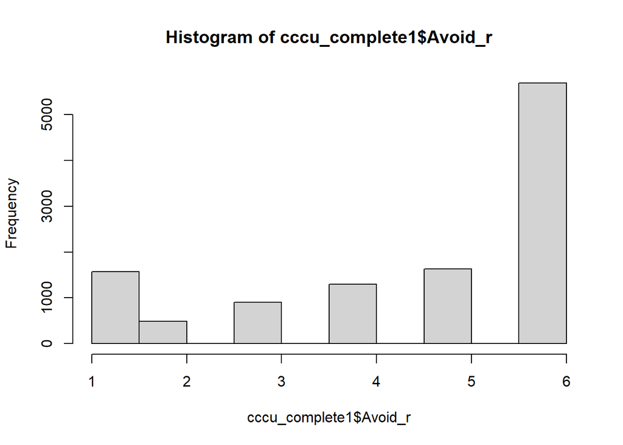

```r
hist(cccu_complete1$Avoid_r)
```

##4.9 FEEL About Pregnancy

```r
#overview
table(cccu_complete1$FEELPG)
```

```
##
##                          (-1) Refused (1) Not at all happy to be pregnant 1
##                                     0                                  2517
##                                 (2) 2                                 (3) 3
##                                  1479                                  1754
##                                 (4) 4                                 (5) 5
##                                  2159                                  1493
##       (6) Very happy to be pregnant 6
##                                  2177
```

```r
crosstabs( ~ FEELPG + WAVE, data = cccu_complete1)
```

```
##                                        WAVE
## FEELPG                                   t1  t2  t3  t4
##   (-1) Refused                            0   0   0   0
##   (1) Not at all happy to be pregnant 1 980 655 511 371
##   (2) 2                                 557 381 283 258
##   (3) 3                                 704 441 355 254
##   (4) 4                                 898 551 392 318
##   (5) 5                                 576 425 283 209
##   (6) Very happy to be pregnant 6       890 566 413 308
```

```r
#recode

cccu_complete1 <- cccu_complete1 %>%
  mutate(FEELPG_recode = ifelse(
    FEELPG == "(1) Not at all happy to be pregnant 1",
    1,
    ifelse(FEELPG == "(2) 2", 2,
           ifelse(
             FEELPG == "(3) 3", 3,
             ifelse(FEELPG == "(4) 4", 4,
                    ifelse(
                      FEELPG == "(5) 5",
                      5,
                      ifelse(FEELPG == "(6) Very happy to be pregnant 6", 6, NA)
                    ))))))


table(cccu_complete1$FEELPG_recode)
```

```
##
##    1    2    3    4    5    6
## 2517 1479 1754 2159 1493 2177
```

```r
sum(is.na(cccu_complete1$FEELPG_recode))
```

```
## [1] 502
```

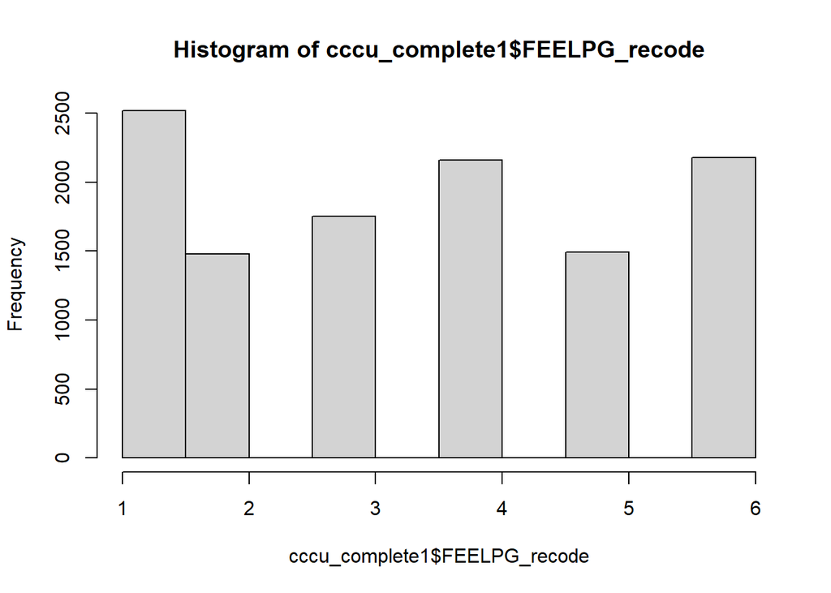

```r
cccu_complete1$FEELPG_recode <-
  as.numeric(cccu_complete1$FEELPG_recode)


hist(cccu_complete1$FEELPG_recode)
```

##4.10 NUMBER of Kids at t1

```r
table(cccu_complete1$NBIRTHS)
```

```
##
##         (0) 0         (1) 1         (2) 2         (3) 3 (4) 4 or more
##          2294           950           865           350           160
```

```r
cccu_complete1 <- cccu_complete1 %>%
  mutate(
    NKIDS_t1 = recode(
      NBIRTHS,
      "(0) 0" = "0",
      "(1) 1" = "1",
      "(2) 2" = "2",
      "(3) 3" = "3",
      "(4) 4 or more" = "4"
    ))

table(cccu_complete1$NKIDS_t1)
```

```
##
##    0    1    2    3    4
## 2294  950  865  350  160
```

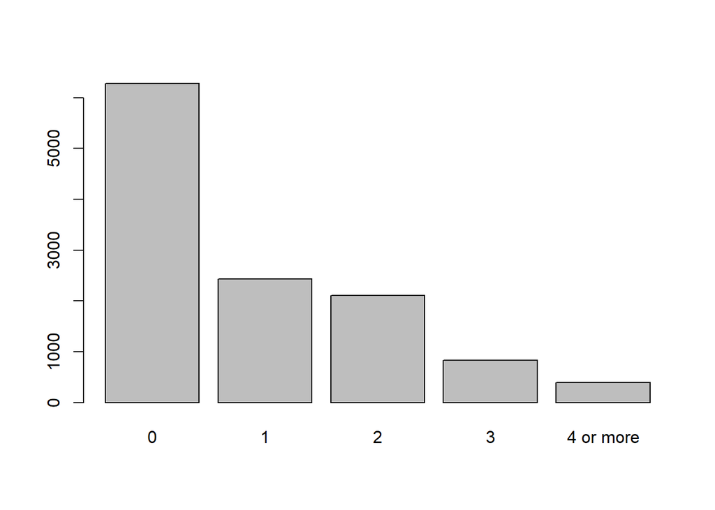

```r
#factorize
cccu_complete1$NKIDS_t1 <-
  factor(
    cccu_complete1$NKIDS_t1,
    levels = c(0, 1, 2, 3,4),
    labels = c("0", "1", "2", "3", "4 or more")
  )


#fill for each wave after t1 (for t2,t3,t4)
cccu_complete1 = cccu_complete1 %>%
  group_by(CASEID) %>%
  fill(NKIDS_t1)


plot(cccu_complete1$NKIDS_t1)
```

##4.11 Pregnant between two waves? Since September 2012, did you experience any of the following?

```r
#overview
table(cccu_complete1$PREG)
```

```
##
##            (-1) Refused (1) I had a miscarriage   (2) I had an abortion
##                       0                     130                      37
##        (3) I had a baby                   (4) I (5) I might be pregnant
##                     273                     425                     196
##   (6) None of the above
##                    6359
```

```r
table(cccu_complete1$CURRENT)
```

```
##
##                               (-1) Refused
##                                          0
## (1) I had a baby within the last 3 months.
##                                        159
##               (2) I am currently pregnant.
##                                          0
##         (3) I might currently be pregnant.
##                                        171
##                     (4) None of the above.
##                                       4287
```

```r
crosstabs( ~ PREG + WAVE, data = cccu_complete1)
```

```
##                          WAVE
## PREG                        t1   t2   t3   t4
##   (-1) Refused               0    0    0    0
##   (1) I had a miscarriage    0   58   44   28
##   (2) I had an abortion      0   17   12    8
##   (3) I had a baby           0   71   93  109
##   (4) I                      0  166  148  111
##   (5) I might be pregnant    0   88   64   44
##   (6) None of the above      0 2798 2027 1534
```

```r
crosstabs( ~ CURRENT + WAVE, data = cccu_complete1)
```

```
##                                             WAVE
## CURRENT                                        t1   t2   t3   t4
##   (-1) Refused                                  0    0    0    0
##   (1) I had a baby within the last 3 months.  159    0    0    0
##   (2) I am currently pregnant.                  0    0    0    0
##   (3) I might currently be pregnant.          171    0    0    0
##   (4) None of the above.                     4287    0    0    0
```

```r
table(is.na(cccu_complete1$PREG))
```

```
##
## FALSE  TRUE
##  7420  4661
```

```r
crosstabs( ~ is.na(PREG) + WAVE, data = cccu_complete1)
```

```
##            WAVE
## is.na(PREG)   t1   t2   t3   t4
##       FALSE    0 3198 2388 1834
##       TRUE  4634    9   10    8
```

```r
crosstabs( ~ is.na(CURRENT) + WAVE, data = cccu_complete1)
```

```
##               WAVE
## is.na(CURRENT)   t1   t2   t3   t4
##          FALSE 4617    0    0    0
##          TRUE    17 3207 2398 1842
```

```r
#PREG is always missing in t1, therefore   replace missing values in PREG with non-missing values in CURRENT
#scale of CURRENT needs to be the same as in PREG

#translate values from CURRENT in scale PREG

cccu_complete1 <- cccu_complete1 %>%
  mutate(
    CURRENT_r = ifelse(
      CURRENT == "(1) I had a baby within the last 3 months.",
      "(3) I had a baby",
      ifelse(
        CURRENT == "(2) I am currently pregnant.",
        "(4) I",
        ifelse(
          CURRENT == "(3) I might currently be pregnant.",
          "(5) I might be pregnant",
          ifelse(CURRENT == "(4) None of the above.", "(6) None of the above", CURRENT)
        ))))

table(cccu_complete1$CURRENT_r)
```

```
##
##        (3) I had a baby (5) I might be pregnant   (6) None of the above
##                     159                     171                    4287
```

```r
#combine values now

cccu_complete1 <- cccu_complete1 %>%
  mutate(PREG_r = ifelse(is.na(PREG), as.character(CURRENT_r), as.character(PREG)))

crosstabs( ~ is.na(PREG_r) + WAVE, data = cccu_complete1)
```

```
##              WAVE
## is.na(PREG_r)   t1   t2   t3   t4
##         FALSE 4617 3198 2388 1834
##         TRUE    17    9   10    8
```

```r
table(cccu_complete1$PREG_r)
```

```
##
## (1) I had a miscarriage   (2) I had an abortion        (3) I had a baby
##                     130                      37                     432
##                   (4) I (5) I might be pregnant   (6) None of the above
##                     425                     367                   10646
```

```r
#recode

cccu_complete1 <- cccu_complete1 %>%
  mutate(
    pregnant_between_waves = ifelse(
      PREG_r == "(1) I had a miscarriage" |
        PREG_r == "(2) I had an abortion" |
        PREG_r == "(3) I had a baby" |
        PREG_r == "(4) I",
      1,
      ifelse(PREG_r == "(-1) Refused", NA, 0)
    ))


table(cccu_complete1$pregnant_between_waves)
```

```
##
##     0     1
## 11013  1024
```

```r
sum(is.na(cccu_complete1$pregnant_between_waves))
```

```
## [1] 44
```

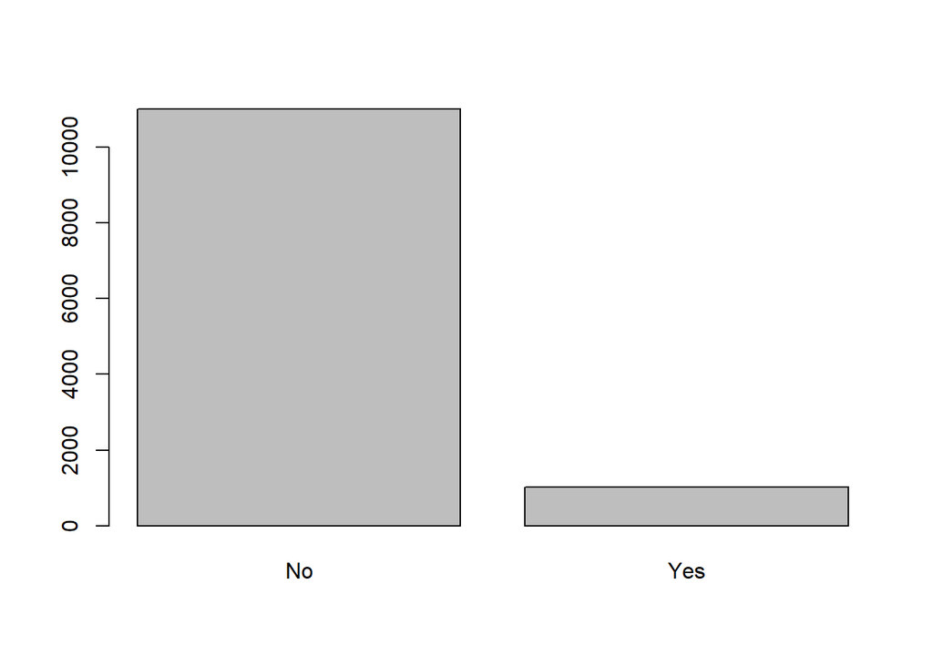

```r
#factorize
cccu_complete1$pregnant_between_waves <-
  factor(
    cccu_complete1$pregnant_between_waves,
    levels = c(0, 1),
    labels = c("No", "Yes")
  )


plot(cccu_complete1$pregnant_between_waves)
```

##4.12 had_baby_between_waves Since September 2012, did you experience any of the following?: I had a baby

```r
#overview
table(cccu_complete1$PREG_r) #<-referring now to PREG_r which combines all PREG values t1-t4
```

```
##
## (1) I had a miscarriage   (2) I had an abortion        (3) I had a baby
##                     130                      37                     432
##                   (4) I (5) I might be pregnant   (6) None of the above
##                     425                     367                   10646
```

```r
table(is.na(cccu_complete1$PREG_r))
```

```
##
## FALSE  TRUE
## 12037    44
```

```r
#recoding in 0 = no baby and 1 = baby

cccu_complete1 <- cccu_complete1 %>%
  mutate(had_baby_between_waves = ifelse(
    PREG_r == "(3) I had a baby",
    1,
    ifelse(PREG_r == "(-1) Refused", NA, 0)
  ))

table(cccu_complete1$had_baby_between_waves)
```

```
##
##     0     1
## 11605   432
```

```r
table(is.na(cccu_complete1$had_baby_between_waves))
```

```
##
## FALSE  TRUE
## 12037    44
```

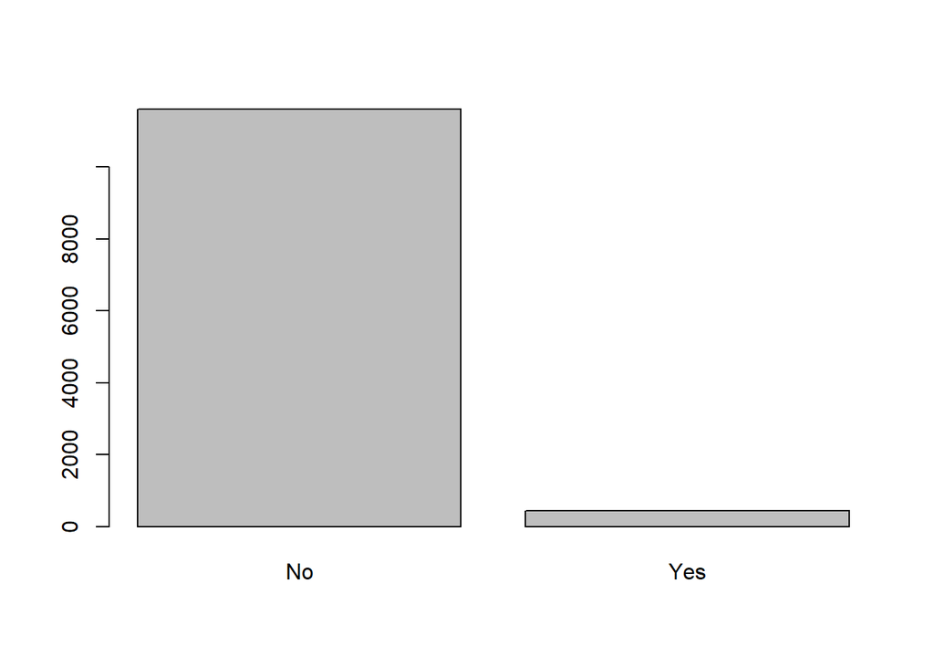

```r
#factorize


cccu_complete1$had_baby_between_waves <-
  factor(
    cccu_complete1$had_baby_between_waves,
    levels = c(0, 1),
    labels = c("No", "Yes")
  )


plot(cccu_complete1$had_baby_between_waves)
```

##4.13 Relationship Duration Relationship information is stored seperately for (items refer to item about gender of partner): * Q3B_A: Married couples * Q3B_B: Non-married but living together couples * Q3B_C: Dating couples (one partner) * Q3B_D1: Dating couples (first of several partners) We exclude any further dating partners (Q3B_D2, Q3B_E1, Q3B_E2)

For dating partners, we have further information, whether the relationship is classified as a “special romantic relationship with each other” (Q4_C and Q4_D1). We only want to count dating relationship as serious relationships, if participants indicated that they are in a romantic relationship.

Therefore, we form a new variable “partnered”, that indicates whether a person is in a relationship (non-missing Q3_A or Q3_B, non-missing Q3B_C and Q4_C == 1, non-missing Q3B_D1 and Q4_D1 == 1), or single (everybody else).

```r
cccu_complete1 <- cccu_complete1 %>%
  mutate(
    partnered = case_when(
    !is.na(Q3B_A) ~ 1,
    !is.na(Q3B_B) ~ 1,
    !is.na(Q3B_C) & Q4_C == 1 ~ 1,
    !is.na(Q3B_D1) & Q4_D1 == 1 ~ 1,
    TRUE ~ 0
    )
  )
crosstabs( ~ Q3B_A + WAVE, data = cccu_complete1)
```

```
##               WAVE
## Q3B_A            t1   t2   t3   t4
##   (-1) Refused    3    3    8    2
##   (0) Female     15   15   18   15
##   (1) Male     2105 1507 1167  931
```

```r
crosstabs( ~ Q3B_B + WAVE, data = cccu_complete1)
```

```
##               WAVE
## Q3B_B           t1  t2  t3  t4
##   (-1) Refused   1   1   1   2
##   (0) Female    32  24  16   8
##   (1) Male     937 599 407 316
```

```r
crosstabs( ~ Q3B_C + Q4_C + WAVE, data = cccu_complete1)
```

```
## , , WAVE = t1
##
##               Q4_C
## Q3B_C          (-1) Refused (0) No (1) Yes (3) Dont Know (4) Didnt care
##   (-1) Refused            0      0       1             0              0
##   (0) Female              0      1      21             2              0
##   (1) Male                4    122     740            60              0
##               Q4_C
## Q3B_C          (2) Yes, though we have broken up and gotten back together during that time
##   (-1) Refused                                                                           0
##   (0) Female                                                                             0
##   (1) Male                                                                               0
##               Q4_C
## Q3B_C          (3) No (4) Unsure
##   (-1) Refused      0          0
##   (0) Female        0          0
##   (1) Male          0          0
##
## , , WAVE = t2
##
##               Q4_C
## Q3B_C          (-1) Refused (0) No (1) Yes (3) Dont Know (4) Didnt care
##   (-1) Refused            0      0       1             0              0
##   (0) Female              0      0      11             0              0
##   (1) Male                3      0     330             0              0
##               Q4_C
## Q3B_C          (2) Yes, though we have broken up and gotten back together during that time
##   (-1) Refused                                                                           1
##   (0) Female                                                                             2
##   (1) Male                                                                              66
##               Q4_C
## Q3B_C          (3) No (4) Unsure
##   (-1) Refused      0          0
##   (0) Female        9          1
##   (1) Male        134          3
##
## , , WAVE = t3
##
##               Q4_C
## Q3B_C          (-1) Refused (0) No (1) Yes (3) Dont Know (4) Didnt care
```

[output cut: 16 more lines]

```
##               Q4_C
## Q3B_C          (-1) Refused (0) No (1) Yes (3) Dont Know (4) Didnt care
##   (-1) Refused            0      0       0             0              0
##   (0) Female              0      0      10             0              0
##   (1) Male                0      0     186             0              0
##               Q4_C
## Q3B_C          (2) Yes, though we have broken up and gotten back together during that time
##   (-1) Refused                                                                           0
##   (0) Female                                                                             1
##   (1) Male                                                                              35
##               Q4_C
## Q3B_C          (3) No (4) Unsure
##   (-1) Refused      0          0
##   (0) Female        1          0
##   (1) Male         69          1
```

```r
crosstabs( ~ Q3B_D1 + Q4_D1 + WAVE, data = cccu_complete1)
```

```
## , , WAVE = t1
##
##               Q4_D1
## Q3B_D1         (-1) Refused (0) No (1) Yes (3) Dont Know (4) Didnt care
##   (-1) Refused            0      0       0             0              0
##   (0) Female              0      1       0             3              0
##   (1) Male                1     52      11             7              0
##               Q4_D1
## Q3B_D1         (2) Yes, though we have broken up and gotten back together during that time
##   (-1) Refused                                                                           0
##   (0) Female                                                                             0
##   (1) Male                                                                               0
##               Q4_D1
## Q3B_D1         (3) No (4) Unsure
##   (-1) Refused      0          0
##   (0) Female        0          0
##   (1) Male          0          0
##
## , , WAVE = t2
##
##               Q4_D1
## Q3B_D1         (-1) Refused (0) No (1) Yes (3) Dont Know (4) Didnt care
##   (-1) Refused            0      0       0             0              0
##   (0) Female              0      0       0             0              0
##   (1) Male                0      0      13             0              0
##               Q4_D1
## Q3B_D1         (2) Yes, though we have broken up and gotten back together during that time
##   (-1) Refused                                                                           0
##   (0) Female                                                                             0
##   (1) Male                                                                              20
##               Q4_D1
## Q3B_D1         (3) No (4) Unsure
##   (-1) Refused      0          0
##   (0) Female        2          0
##   (1) Male         17          2
##
## , , WAVE = t3
##
##               Q4_D1
## Q3B_D1         (-1) Refused (0) No (1) Yes (3) Dont Know (4) Didnt care
```

[output cut: 16 more lines]

```
##               Q4_D1
## Q3B_D1         (-1) Refused (0) No (1) Yes (3) Dont Know (4) Didnt care
##   (-1) Refused            0      0       0             0              0
##   (0) Female              0      0       1             0              0
##   (1) Male                0      0       4             0              0
##               Q4_D1
## Q3B_D1         (2) Yes, though we have broken up and gotten back together during that time
##   (-1) Refused                                                                           0
##   (0) Female                                                                             0
##   (1) Male                                                                               9
##               Q4_D1
## Q3B_D1         (3) No (4) Unsure
##   (-1) Refused      0          0
##   (0) Female        0          0
##   (1) Male          6          0
```

```r
table(cccu_complete1$partnered)
```

```
##
##    0    1
## 3954 8127
```

```r
crosstabs( ~ partnered + WAVE, data = cccu_complete1)
```

```
##          WAVE
## partnered   t1   t2   t3   t4
##         0 1547 1058  781  568
##         1 3087 2149 1617 1274
```

For relationship duration we need to combine items MONTHSA, MONTHSB, MONTHSC and MONTHSD1 (with a descending hierarchy). Same needs to be done for YEARSA, YEARSB, YEARSC and YEARSD1. We will first combine them in two columnes (rel_dur_months and rel_dur_years).

```r
cccu_complete1 <- cccu_complete1 %>%
  mutate(
    rel_dur_months = case_when(
      !is.na(Q3B_A) ~ MONTHSA,
      !is.na(Q3B_B) ~ MONTHSB,
      !is.na(Q3B_C) & Q4_C == 1 ~ MONTHSC,
      !is.na(Q3B_D1) & Q4_D1 == 1 ~ MONTHSD1
    ),
    rel_dur_years = case_when(
      !is.na(Q3B_A) ~ YEARSA,
      !is.na(Q3B_B) ~ YEARSB,
      !is.na(Q3B_C) & Q4_C == 1 ~ YEARSC,
      !is.na(Q3B_D1) & Q4_D1 == 1 ~ YEARSD1
    ),
  )

table(is.na(cccu_complete1$rel_dur_months))
```

```
##
## FALSE  TRUE
##  8127  3954
```

```r
table(is.na(cccu_complete1$rel_dur_years))
```

```
##
## FALSE  TRUE
##  3087  8994
```

```r
table(cccu_complete1$rel_dur_months)
```

```
##
##    0    1    2    3    4    5    6    7    8    9   10   11   14   18   20   45
## 5974  228  251  211  196  184  300  136  140  158  140  201    1    1    1    1
##   48   72  120  200
##    1    1    1    1
```

```r
table(cccu_complete1$rel_dur_years)
```

```
##
##    0   12   24   36   48   60   72   84   96  108  120  132  144  156  168  180
##   98  157  196  253  277  294  219  248  206  169  193  136  151  102   90   84
##  192  204  216  228  240  252  264  276  288  300  324  372  456  540  624 1380
##   53   46   37   23   21    9   12    4    2    1    1    1    1    1    1    1
```

```r
crosstabs( ~ MONTHSA + WAVE, data = cccu_complete1)
```

```
##        WAVE
## MONTHSA   t1   t2   t3   t4
##     0   3245 3198 2395 1841
##     1    142    2    0    0
##     2    167    1    0    0
##     3    149    1    0    0
##     4    125    0    1    0
##     5    110    3    1    1
##     6    201    0    1    0
##     7     87    0    0    0
##     8     89    0    0    0
##     9     85    0    0    0
##     10    97    0    0    0
##     11   137    0    0    0
##     48     0    1    0    0
##     200    0    1    0    0
```

```r
crosstabs( ~ rel_dur_years + WAVE, data = cccu_complete1)
```

```
##              WAVE
## rel_dur_years   t1   t2   t3   t4
##          0      98    0    0    0
##          12    157    0    0    0
##          24    196    0    0    0
##          36    253    0    0    0
##          48    277    0    0    0
##          60    294    0    0    0
##          72    219    0    0    0
##          84    248    0    0    0
##          96    206    0    0    0
##          108   169    0    0    0
##          120   193    0    0    0
##          132   136    0    0    0
##          144   151    0    0    0
```

[output cut: 20 more lines]

Now we combine years and months to one variable rel_dur (in months).

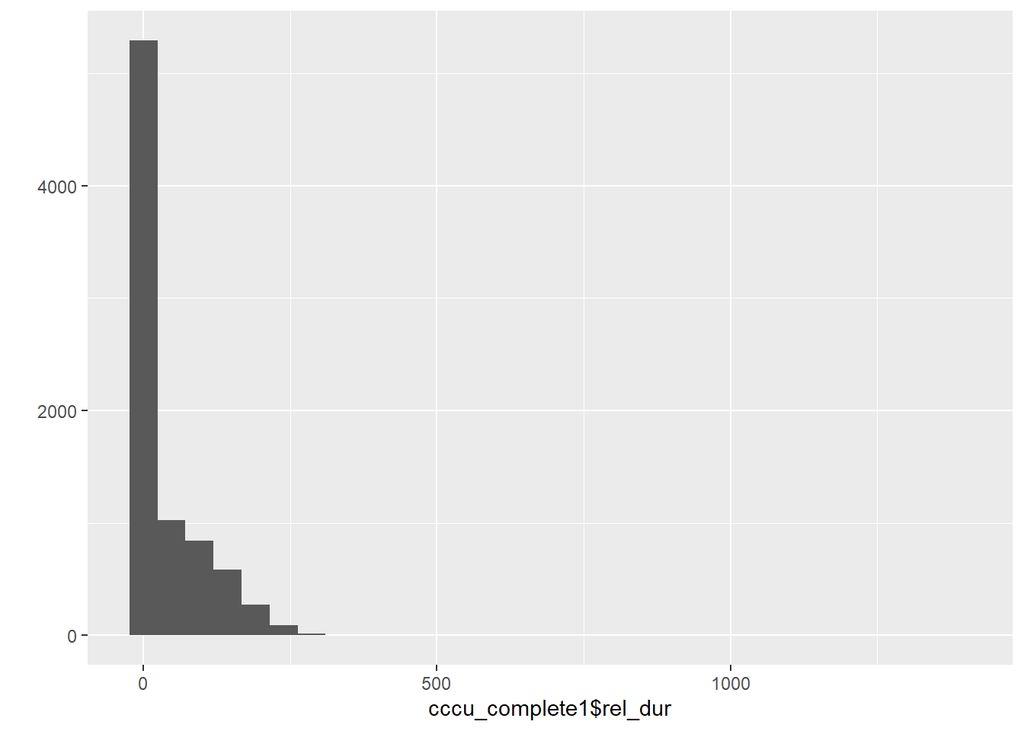

```r
cccu_complete1 <- cccu_complete1 %>%
  mutate(rel_dur = rel_dur_years + rel_dur_months,
         rel_dur = ifelse(is.na(rel_dur), rel_dur_months, rel_dur))

library(ggplot2)
qplot(cccu_complete1$rel_dur)
```

```r
crosstabs( ~ rel_dur + WAVE, data = cccu_complete1)
```

```
##        WAVE
## rel_dur   t1   t2   t3   t4
##    0      14 2125 1602 1267
##    1       1    3    0    1
##    2       6    3    2    0
##    3       2    4    2    0
##    4       6    2    5    0
##    5      11    5    2    3
##    6      10    0    2    1
##    7      11    0    0    0
##    8      12    1    0    1
##    9      14    0    0    1
##    10      3    0    0    0
##    11      8    0    0    0
##    12     19    0    0    0
```

[output cut: 250 more lines]

adding six month to rel dur if patnered = still yes

```r
cccu_complete1 = cccu_complete1 %>%
 group_by(CASEID)%>%#t2
  mutate(rel_dur_lag = lag(rel_dur))%>%
  mutate(rel_dur = ifelse(rel_dur == 0 & partnered == 1 & WAVE == "t2", (rel_dur_lag+6), rel_dur))%>%#t3
  mutate(rel_dur_lag = lag(rel_dur))%>%
  mutate(rel_dur = ifelse(rel_dur == 0 & partnered == 1 & WAVE == "t3", (rel_dur_lag+6), rel_dur))%>%#t4
  mutate(rel_dur_lag = lag(rel_dur))%>%
  mutate(rel_dur = ifelse(rel_dur == 0 & partnered == 1 & WAVE == "t4", (rel_dur_lag+6), rel_dur))%>%
  ungroup()

cccu_complete1 = cccu_complete1 %>%
mutate(rel_dur = ifelse(is.na(rel_dur), rel_dur_months, rel_dur))

crosstabs( ~ rel_dur + partnered, data = cccu_complete1)
```

```
##        partnered
## rel_dur    0    1
##    0       0  511
##    1       0    5
##    2       0   11
##    3       0    8
##    4       0   13
##    5       0   21
##    6       0   20
##    7       0   13
##    8       0   17
##    9       0   18
##    10      0    8
##    11      0   15
##    12      0   31
```

[output cut: 295 more lines]

```r
cccu_complete1 %>% select(CASEID, WAVE, rel_dur, rel_dur_lag, partnered) %>% View()
```

To incorporate relationship status and relationship duration in one variable we need a factor variable rel_dur_factor that includes five categories: *singles* partnered, relationship duration in <25%-quartile *partnered, relationship duration in 25 - 50%-quartile* partnered, relationship duration in 50 - 75%-quartile *partnered, relationship duration in >75%-quartile This way all partnered categories are the same size.

```r
quantile(cccu_complete1$rel_dur, na.rm = T)
```

```
##   0%  25%  50%  75% 100%
##    0   50   89  138 1391
```

```r
cccu_complete1 <- cccu_complete1 %>%
  mutate(
    rel_dur_factor = case_when(
      is.na(rel_dur) ~ "Single",
      rel_dur <= quantile(cccu_complete1$rel_dur, na.rm = T)[[2]] ~ "0q-25q",
      rel_dur <= quantile(cccu_complete1$rel_dur, na.rm = T)[[3]] ~ "26q-50q",
      rel_dur <= quantile(cccu_complete1$rel_dur, na.rm = T)[[4]] ~ "51q-75q",
      rel_dur > quantile(cccu_complete1$rel_dur, na.rm = T)[[4]] ~ "76q-100q",
    )
  )

cccu_complete1$rel_dur_factor <- factor(cccu_complete1$rel_dur_factor,
                                             levels = c("Single", "0q-25q", "26q-50q", "51q-75q",
                                                        "76q-100q"),
                                             labels = c("Single", "0q-25q", "26q-50q", "51q-75q",
                                                        "76q-100q"))

table(is.na(cccu_complete1$rel_dur_factor))
```

```
##
## FALSE
## 12081
```

```r
crosstabs(~rel_dur + rel_dur_factor, data = cccu_complete1)
```

```
##        rel_dur_factor
## rel_dur Single 0q-25q 26q-50q 51q-75q 76q-100q
##    0         0    511       0       0        0
##    1         0      5       0       0        0
##    2         0     11       0       0        0
##    3         0      8       0       0        0
##    4         0     13       0       0        0
##    5         0     21       0       0        0
##    6         0     20       0       0        0
##    7         0     13       0       0        0
##    8         0     17       0       0        0
##    9         0     18       0       0        0
##    10        0      8       0       0        0
##    11        0     15       0       0        0
##    12        0     31       0       0        0
```

[output cut: 295 more lines]

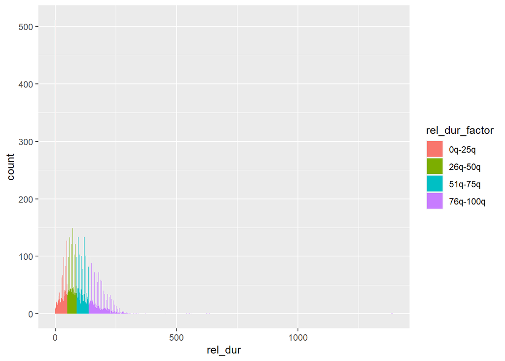

```r
ggplot(aes(rel_dur,  fill = rel_dur_factor), data = cccu_complete1) + geom_histogram(binwidth = 1)
```

```r
crosstabs( ~ rel_dur_factor + WAVE, data = cccu_complete1)
```

```
##               WAVE
## rel_dur_factor   t1   t2   t3   t4
##       Single   1547 1058  781  568
##       0q-25q    833  529  392  309
##       26q-50q   828  524  390  288
##       51q-75q   749  576  404  341
##       76q-100q  677  520  431  336
```

##4.14 SEXUAL SATISFACTION: How satisfied is R in his / her sexual relationship?

```r
#overview
table(cccu_complete1$SEXSAT)
```

```
##
##    1    2    3    4    5    6    7
##  222  346  745 1718 2534 4614  225
```

```r
crosstabs( ~ SEXSAT+ WAVE, data = cccu_complete1)
```

```
##       WAVE
## SEXSAT   t1   t2   t3   t4
##   1      70   64   49   39
##   2     139   76   77   54
##   3     276  212  147  110
##   4     648  455  329  286
##   5     899  695  527  413
##   6    1880 1188  888  658
##   7      99   60   37   29
##   <NA>  623  457  344  253
```

```r
#recoding
cccu_complete1 <- cccu_complete1 %>%
  mutate(sexual_satisfaction = ifelse(SEXSAT == "1", 1,
                                      ifelse(
                                        SEXSAT == "2", 2,
                                        ifelse(SEXSAT == "3", 3,
                                               ifelse(
                                                 SEXSAT == "4", 4,
                                                 ifelse(SEXSAT == "5", 5, ifelse(SEXSAT == "6", 6, NA)))))))


cccu_complete1$sexual_satisfaction <-
  as.numeric(cccu_complete1$sexual_satisfaction)

table(cccu_complete1$sexual_satisfaction)
```

```
##
##    1    2    3    4    5    6
##  222  346  745 1718 2534 4614
```

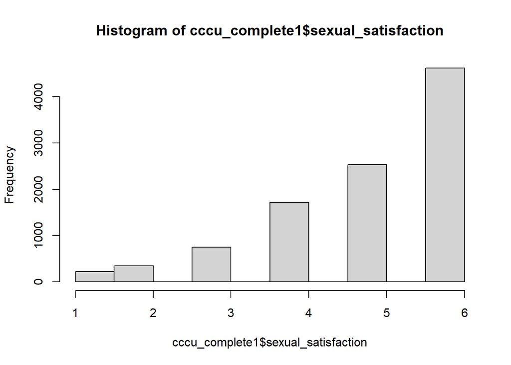

```r
hist(cccu_complete1$sexual_satisfaction)
```

## 4.15 SEX In LAST 30 days? SEXMO

```r
#overview
table(cccu_complete1$SEXMO)
```

```
##
##   (-1) Refused         (0) No        (1) Yes  (3) Dont Know (4) Didnt care
##             21           2657           9328              0              0
```

```r
crosstabs( ~ SEXMO + WAVE, data = cccu_complete1)
```

```
##                 WAVE
## SEXMO              t1   t2   t3   t4
##   (-1) Refused      0    0    0   21
##   (0) No          963  698  565  431
##   (1) Yes        3649 2479 1810 1390
##   (3) Dont Know     0    0    0    0
##   (4) Didnt care    0    0    0    0
```

```r
#recoding
cccu_complete1 <- cccu_complete1 %>%
  mutate(
    sex_inlast30days = recode(
      SEXMO,
      "(-1) Refused" = "NA",
      "(0) No" = "0",
      "(1) Yes" = "1",
      "(3) Dont Know" = "NA",
      "(4) Didnt care" = "NA"
    )
  )
table(cccu_complete1$sex_inlast30days)
```

```
##
##   NA    0    1
##   21 2657 9328
```

```r
#factorize
cccu_complete1$sex_inlast30days <-
  factor(
    cccu_complete1$sex_inlast30days,
    levels = c(0, 1),
    labels = c("No", "Yes")
  )

sum(is.na(cccu_complete1$sex_inlast30days))
```

```
## [1] 96
```

##4.16 Sexual Frequency: NSEXMO: how many times sex in last 30 days

```r
#overview:
table(cccu_complete1$NSEXMO)
```

```
##
##   (-1) Refused          (1) 1        (2) 2-5       (3) 6-10 (4) 11 or more
##              0            764           4157           2687           1660
```

```r
crosstabs( ~ NSEXMO + WAVE, data = cccu_complete1)
```

```
##                 WAVE
## NSEXMO             t1   t2   t3   t4
##   (-1) Refused      0    0    0    0
##   (1) 1           293  215  138  118
##   (2) 2-5        1624 1079  835  619
##   (3) 6-10       1014  730  530  413
##   (4) 11 or more  693  441  295  231
```

```r
#overview
table(cccu_complete1$sex_inlast30days)
```

```
##
##   No  Yes
## 2657 9328
```

```r
#building sexual frequency: if sex_inlast30days = 0 ("No") we want 0, if NSEXMO = 1 we want 1, if NSEXMO 2 = 2, 3 =3, 4 = 4, otherwise NA

cccu_complete1 <- cccu_complete1 %>%
  mutate(sex_freq = ifelse(sex_inlast30days == "No", 1,
                           ifelse(
                             NSEXMO == "(1) 1", 1,
                             ifelse(NSEXMO == "(2) 2-5", 2,
                                    ifelse(
                                      NSEXMO == "(3) 6-10", 3,
                                      ifelse(NSEXMO == "(4) 11 or more", 4, NA)
                                    ))
                           )))

table(cccu_complete1$sex_freq)
```

```
##
##    1    2    3    4
## 3421 4157 2687 1660
```

```r
crosstabs(~sex_inlast30days + NSEXMO , data = cccu_complete1)
```

```
##                 NSEXMO
## sex_inlast30days (-1) Refused (1) 1 (2) 2-5 (3) 6-10 (4) 11 or more
##              No             0     0       0        0              0
##              Yes            0   764    4157     2687           1660
```

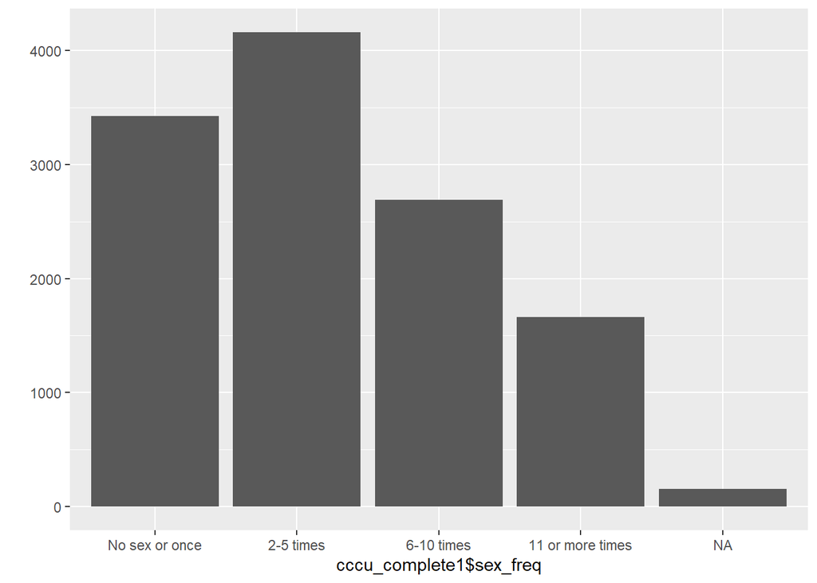

```r
#factorize
cccu_complete1$sex_freq <-
  factor(
    cccu_complete1$sex_freq,
    levels = c(1, 2, 3, 4),
    labels = c("No sex or once", "2-5 times", "6-10 times", "11 or more times")
  )

qplot(cccu_complete1$sex_freq)
```

##4.19 hc use:grouping

```r
crosstabs( ~ PILL + WAVE, data = cccu_complete1)
```

```
##          WAVE
## PILL        t1   t2   t3   t4
##   (0) No  3192 2233 1674 1277
##   (1) Yes 1442  974  724  565
```

```r
crosstabs( ~ PATCH+ WAVE, data = cccu_complete1)
```

```
##          WAVE
## PATCH       t1   t2   t3   t4
##   (0) No  4611 3192 2392 1836
##   (1) Yes   23   15    6    6
```

```r
crosstabs( ~ RING + WAVE, data = cccu_complete1)
```

```
##          WAVE
## RING        t1   t2   t3   t4
##   (0) No  4496 3113 2341 1800
##   (1) Yes  138   94   57   42
```

```r
crosstabs( ~ DEPO + WAVE, data = cccu_complete1)
```

```
##          WAVE
## DEPO        t1   t2   t3   t4
##   (0) No  4443 3097 2321 1794
##   (1) Yes  191  110   77   48
```

```r
crosstabs( ~ IMPLANT + WAVE, data = cccu_complete1)
```

```
##          WAVE
## IMPLANT     t1   t2   t3   t4
##   (0) No  4553 3157 2360 1811
##   (1) Yes   81   50   38   31
```

```r
crosstabs( ~ IUD+ WAVE, data = cccu_complete1)
```

```
##          WAVE
## IUD         t1   t2   t3   t4
##   (0) No  4154 2899 2162 1652
##   (1) Yes  480  308  236  190
```

```r
crosstabs( ~ CONDOMR + WAVE, data = cccu_complete1)
```

```
##          WAVE
## CONDOMR     t1   t2   t3   t4
##   (0) no  2506 1765 1307 1034
##   (1) yes 1143  714  503  356
```

```r
crosstabs( ~ VASECTOMY+ WAVE, data = cccu_complete1)
```

```
##          WAVE
## VASECTOMY   t1   t2   t3   t4
##   (0) No  3483 2357 1720 1310
##   (1) Yes    0   19   25   35
```

```r
crosstabs( ~ WITHDRAWR+ WAVE, data = cccu_complete1)
```

```
##          WAVE
## WITHDRAWR   t1   t2   t3   t4
##   (0) no  2531 1776 1347 1032
##   (1) yes 1118  703  463  358
```

```r
crosstabs( ~ NFPR + WAVE, data = cccu_complete1)
```

```
##          WAVE
## NFPR        t1   t2   t3   t4
##   (0) no  3477 2360 1722 1315
##   (1) yes  172  119   88   75
```

```r
crosstabs( ~ SPERMR + WAVE, data = cccu_complete1)
```

```
##          WAVE
## SPERMR      t1   t2   t3   t4
##   (0) no  3580 2447 1785 1371
##   (1) yes   69   32   25   19
```

```r
crosstabs( ~ NOBARRIER + WAVE, data = cccu_complete1)
```

```
##          WAVE
## NOBARRIER   t1   t2   t3   t4
##   (0) No  1866 1192  843  630
##   (1) Yes 1617 1184  902  715
```

```r
cccu_complete1 <- cccu_complete1 %>%
  mutate(hc = ifelse(PILL %contains% "1"|
                       PATCH %contains% "1" |
                       RING %contains% "1" |
                       DEPO %contains% "1" |
                       IMPLANT %contains% "1", 1,
                      ifelse(IUD %contains% "1", 2,
                             ifelse(CONDOMR %contains% "1"| #actively include non_hc user as 0
                                     VASECTOMY %contains% "1"|
                                     WITHDRAWR %contains% "1" |
                                     NFPR %contains% "1" |
                                     SPERMR %contains% "1" |
                                     NOBARRIER %contains% "1", 0, NA))),
         hc = ifelse(PILL %contains% "0" &
                       PATCH %contains% "0" &
                       RING %contains% "0" &
                       DEPO %contains% "0" &
                       IMPLANT %contains% "0" &
                        IUD %contains% "0", 0, hc))


table(cccu_complete1$hc)
```

```
##
##    0    1    2
## 6248 4654 1179
```

```r
table(is.na(cccu_complete1$hc))
```

```
##
## FALSE
## 12081
```

```r
crosstabs(~IUD + hc, data = cccu_complete1)
```

```
##          hc
## IUD          0    1    2
##   (0) No  6248 4619    0
##   (1) Yes    0   35 1179
```

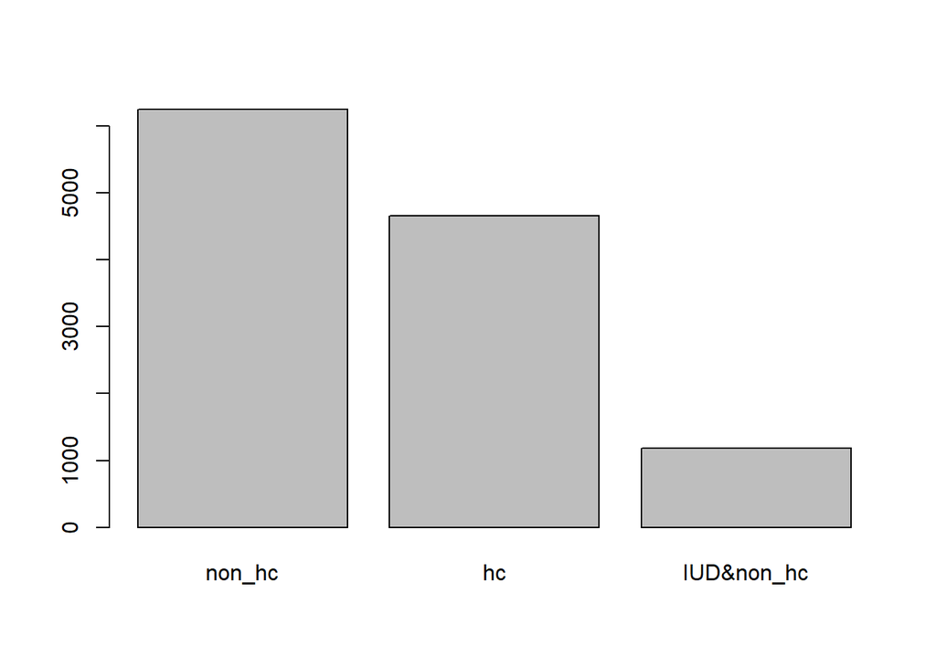

```r
#factorizing
cccu_complete1$hc <-
  factor(
    cccu_complete1$hc,
    levels = c(0, 1, 2),
    labels = c("non_hc", "hc", "IUD&non_hc")
  )


plot(cccu_complete1$hc)
```

##4.19.1 Building IUD next

```r
cccu_complete1 <- cccu_complete1 %>%
  group_by(CASEID) %>%
  mutate(IUD_next = lead(IUD)) %>%
  ungroup()

cccu_complete1 %>% select(CASEID, WAVE, IUD, IUD_next) %>% View()
```

##4.20 Contraceptive Satisfaction

```r
table(cccu_complete1$hc)
```

```
##
##     non_hc         hc IUD&non_hc
##       6248       4654       1179
```

```r
#recoding values for hc satisfaction (note: 1 = very satisfied, for hypotheses 1 must be very dissatisfied)

##pill
table(cccu_complete1$Q23D_PILL)
```

```
##
##              (-1) Refused        (1) Very satisfied    (2) Somewhat satisfied
##                        17                      2340                      1112
## (3) Somewhat dissatisfied     (4) Very dissatisfied
##                       181                        59
```

```r
crosstabs( ~ Q23D_PILL + WAVE, data = cccu_complete1)
```

```
##                            WAVE
## Q23D_PILL                    t1  t2  t3  t4
##   (-1) Refused                6   5   5   1
##   (1) Very satisfied        877 634 468 361
##   (2) Somewhat satisfied    460 276 199 177
##   (3) Somewhat dissatisfied  74  48  41  18
##   (4) Very dissatisfied      29  11  11   8
```

```r
cccu_complete1 <- cccu_complete1 %>%
  mutate(Q23D_PILL_r = ifelse(
    Q23D_PILL %contains% "(1)",
    4,
    ifelse(
      Q23D_PILL %contains% "(2)",
      3,
      ifelse(
        Q23D_PILL %contains% "(3)",
        2,
        ifelse(Q23D_PILL %contains% "(4)", 1, NA)
      ))))

table(cccu_complete1$Q23D_PILL_r)
```

```
##
##    1    2    3    4
##   59  181 1112 2340
```

```r
##Patch

table(cccu_complete1$Q23D_PATCH)
```

```
##
##              (-1) Refused        (1) Very satisfied    (2) Somewhat satisfied
##                         2                        28                        15
## (3) Somewhat dissatisfied     (4) Very dissatisfied
##                         4                         2
```

```r
crosstabs( ~ Q23D_PATCH + WAVE, data = cccu_complete1)
```

```
##                            WAVE
## Q23D_PATCH                  t1 t2 t3 t4
##   (-1) Refused               1  1  0  0
##   (1) Very satisfied        12  9  4  3
##   (2) Somewhat satisfied     7  3  2  3
##   (3) Somewhat dissatisfied  3  1  0  0
##   (4) Very dissatisfied      1  1  0  0
```

```r
cccu_complete1 <- cccu_complete1 %>%
  mutate(Q23D_PATCH_r = ifelse(
    Q23D_PATCH %contains% "(1)",
    4,
    ifelse(
      Q23D_PATCH %contains% "(2)",
      3,
      ifelse(
        Q23D_PATCH %contains% "(3)",
        2,
        ifelse(Q23D_PATCH %contains% "(4)", 1, NA)
      )
    )
  ))

table(cccu_complete1$Q23D_PATCH_r)
```

```
##
##  1  2  3  4
##  2  4 15 28
```

```r
##Depo
table(cccu_complete1$Q23D_DEPO)
```

```
##
##              (-1) Refused        (1) Very satisfied    (2) Somewhat satisfied
##                         4                       290                        97
## (3) Somewhat dissatisfied     (4) Very dissatisfied
##                        16                        20
```

```r
crosstabs( ~ Q23D_DEPO + WAVE, data = cccu_complete1)
```

```
##                            WAVE
## Q23D_DEPO                    t1  t2  t3  t4
##   (-1) Refused                2   2   0   0
##   (1) Very satisfied        127  76  52  35
##   (2) Somewhat satisfied     45  25  16  11
##   (3) Somewhat dissatisfied   7   4   5   0
##   (4) Very dissatisfied      11   3   4   2
```

```r
cccu_complete1 <- cccu_complete1 %>%
  mutate(Q23D_DEPO_r = ifelse(
    Q23D_DEPO %contains% "(1)",
    4,
    ifelse(
      Q23D_DEPO %contains% "(2)",
      3,
      ifelse(
        Q23D_DEPO %contains% "(3)",
        2,
        ifelse(Q23D_DEPO %contains% "(4)", 1, NA)
      )
    )
  ))

table(cccu_complete1$Q23D_DEPO_r)
```

```
##
##   1   2   3   4
##  20  16  97 290
```

```r
##Implant
table(cccu_complete1$Q23D_IMPLANT)
```

```
##
##              (-1) Refused        (1) Very satisfied    (2) Somewhat satisfied
##                         2                       138                        36
## (3) Somewhat dissatisfied     (4) Very dissatisfied
##                        16                         8
```

```r
crosstabs( ~ Q23D_IMPLANT + WAVE, data = cccu_complete1)
```

```
##                            WAVE
## Q23D_IMPLANT                t1 t2 t3 t4
##   (-1) Refused               0  1  1  0
##   (1) Very satisfied        54 39 26 19
##   (2) Somewhat satisfied    15  6  7  8
##   (3) Somewhat dissatisfied  6  3  3  4
##   (4) Very dissatisfied      6  1  1  0
```

```r
cccu_complete1 <- cccu_complete1 %>%
  mutate(Q23D_IMPLANT_r = ifelse(
    Q23D_IMPLANT %contains% "(1)",
    4,
    ifelse(
      Q23D_IMPLANT %contains% "(2)",
      3,
      ifelse(
        Q23D_IMPLANT %contains% "(3)",
        2,
        ifelse(Q23D_IMPLANT %contains% "(4)", 1, NA)
      )
    )
  ))

table(cccu_complete1$Q23D_IMPLANT_r)
```

```
##
##   1   2   3   4
##   8  16  36 138
```

```r
##Ring
table(cccu_complete1$Q23D_RING)
```

```
##
##              (-1) Refused        (1) Very satisfied    (2) Somewhat satisfied
##                         5                       260                        53
## (3) Somewhat dissatisfied     (4) Very dissatisfied
##                         8                         7
```

```r
crosstabs( ~ Q23D_RING + WAVE, data = cccu_complete1)
```

```
##                            WAVE
## Q23D_RING                    t1  t2  t3  t4
##   (-1) Refused                2   2   1   0
##   (1) Very satisfied        106  72  48  34
##   (2) Somewhat satisfied     22  20   6   5
##   (3) Somewhat dissatisfied   4   0   1   3
##   (4) Very dissatisfied       6   0   1   0
```

```r
cccu_complete1 <- cccu_complete1 %>%
  mutate(Q23D_RING_r = ifelse(
    Q23D_RING %contains% "(1)",
    4,
    ifelse(
      Q23D_RING %contains% "(2)",
      3,
      ifelse(
        Q23D_RING %contains% "(3)",
        2,
        ifelse(Q23D_RING %contains% "(4)", 1, NA)
      )
    )
  ))

table(cccu_complete1$Q23D_RING_r)
```

```
##
##   1   2   3   4
##   7   8  53 260
```

```r
#recoding non-hc satisfaction values

#withdrawl

table(cccu_complete1$RSAT1)
```

```
##
## (000) didnâ€™t use/not applicable              (001) very satisfied
##                              3419                               932
##          (002) somewhat satisfied       (003) somewhat dissatisfied
##                              1125                               409
##              (004) very satisfied                  (005) don't know
##                               162                                 0
##                  (100) don't know
##                                 0
```

```r
crosstabs( ~ RSAT1 + WAVE, data = cccu_complete1)
```

```
##                                    WAVE
## RSAT1                                 t1   t2   t3   t4
##   (000) didnâ€™t use/not applicable    0    0 1935 1484
##   (001) very satisfied               392  246  172  122
##   (002) somewhat satisfied           472  298  208  147
##   (003) somewhat dissatisfied        175  121   54   59
##   (004) very satisfied                75   31   29   27
##   (005) don't know                     0    0    0    0
##   (100) don't know                     0    0    0    0
```

```r
cccu_complete1 <- cccu_complete1 %>%
  mutate(RSAT1_r = ifelse(
    RSAT1 %contains% "(001)",
    4,
    ifelse(
      RSAT1 %contains% "(002)",
      3,
      ifelse(
        RSAT1 %contains% "(003)",
        2,
        ifelse(RSAT1 %contains% "(004)", 1, NA)
      )
    )
  ))

table(cccu_complete1$RSAT1_r)
```

```
##
##    1    2    3    4
##  162  409 1125  932
```

```r
##vasectomy
table(cccu_complete1$RSAT2)
```

```
##
## (000) didnâ€™t use/not applicable              (001) very satisfied
##                              7363                                63
##          (002) somewhat satisfied       (003) somewhat dissatisfied
##                                15                                 5
##              (004) very satisfied                  (005) don't know
##                                 2                                 0
##                  (100) don't know
##                                 0
```

```r
crosstabs( ~ RSAT2 + WAVE, data = cccu_complete1)
```

```
##                                    WAVE
## RSAT2                                 t1   t2   t3   t4
##   (000) didnâ€™t use/not applicable    0 3186 2370 1807
##   (001) very satisfied                 1   12   21   29
##   (002) somewhat satisfied             0    7    4    4
##   (003) somewhat dissatisfied          0    1    2    2
##   (004) very satisfied                 0    1    1    0
##   (005) don't know                     0    0    0    0
##   (100) don't know                     0    0    0    0
```

```r
cccu_complete1 <- cccu_complete1 %>%
  mutate(RSAT2_r = ifelse(
    RSAT2 %contains% "(001)",
    4,
    ifelse(
      RSAT2 %contains% "(002)",
      3,
      ifelse(
        RSAT2 %contains% "(003)",
        2,
        ifelse(RSAT2 %contains% "(004)", 1, NA)
      )
    )
  ))

table(cccu_complete1$RSAT2_r)
```

```
##
##  1  2  3  4
##  2  5 15 63
```

```r
##condoms
table(cccu_complete1$RSAT3)
```

```
##
## (000) didnâ€™t use/not applicable              (001) very satisfied
##                              1895                              1043
##          (002) somewhat satisfied       (003) somewhat dissatisfied
##                              1188                               341
##              (004) very satisfied                  (005) don't know
##                               136                                 0
##                  (100) don't know
##                                 0
```

```r
crosstabs( ~ RSAT3 + WAVE, data = cccu_complete1)
```

```
##                                    WAVE
## RSAT3                                 t1   t2   t3   t4
##   (000) didnâ€™t use/not applicable    0    0 1895    0
##   (001) very satisfied               415  276  200  152
##   (002) somewhat satisfied           509  306  224  149
##   (003) somewhat dissatisfied        153   91   56   41
##   (004) very satisfied                60   39   23   14
##   (005) don't know                     0    0    0    0
##   (100) don't know                     0    0    0    0
```

```r
cccu_complete1 <- cccu_complete1 %>%
  mutate(RSAT3_r = ifelse(
    RSAT3 %contains% "(001)",
    4,
    ifelse(
      RSAT3 %contains% "(002)",
      3,
      ifelse(
        RSAT3 %contains% "(003)",
        2,
        ifelse(RSAT3 %contains% "(004)", 1, NA)
      )
    )
  ))

table(cccu_complete1$RSAT3_r)
```

```
##
##    1    2    3    4
##  136  341 1188 1043
```

```r
##natural /calender

table(cccu_complete1$RSAT4)
```

```
##
## (000) didnâ€™t use/not applicable              (001) very satisfied
##                              2310                               223
##          (002) somewhat satisfied       (003) somewhat dissatisfied
##                               177                                42
##              (004) very satisfied                  (005) don't know
##                                 9                                 0
##                  (100) don't know
##                                 0
```

```r
crosstabs( ~ RSAT4 + WAVE, data = cccu_complete1)
```

```
##                                    WAVE
## RSAT4                                 t1   t2   t3   t4
##   (000) didnâ€™t use/not applicable    0    0 2310    0
##   (001) very satisfied                82   64   42   35
##   (002) somewhat satisfied            72   40   35   30
##   (003) somewhat dissatisfied         13   12    9    8
##   (004) very satisfied                 4    1    2    2
##   (005) don't know                     0    0    0    0
##   (100) don't know                     0    0    0    0
```

```r
cccu_complete1 <- cccu_complete1 %>%
  mutate(RSAT4_r = ifelse(
    RSAT4 %contains% "(001)",
    4,
    ifelse(
      RSAT4 %contains% "(002)",
      3,
      ifelse(
        RSAT4 %contains% "(003)",
        2,
        ifelse(RSAT4 %contains% "(004)", 1, NA)
      )
    )
  ))

table(cccu_complete1$RSAT4_r)
```

```
##
##   1   2   3   4
##   9  42 177 223
```

```r
##spermicid

table(cccu_complete1$RSAT5)
```

```
##
## (000) didnâ€™t use/not applicable              (001) very satisfied
##                              2373                                61
##          (002) somewhat satisfied       (003) somewhat dissatisfied
##                                65                                13
##              (004) very satisfied                  (005) don't know
##                                 5                                 0
##                  (100) don't know                          (-01) -1
##                                 0                                 1
```

```r
crosstabs( ~ RSAT5 + WAVE, data = cccu_complete1)
```

```
##                                    WAVE
## RSAT5                                 t1   t2   t3   t4
##   (000) didnâ€™t use/not applicable    0    0 2373    0
##   (001) very satisfied                29   16   11    5
##   (002) somewhat satisfied            34   11   11    9
##   (003) somewhat dissatisfied          4    3    3    3
##   (004) very satisfied                 2    2    0    1
##   (005) don't know                     0    0    0    0
##   (100) don't know                     0    0    0    0
##   (-01) -1                             0    0    0    1
```

```r
cccu_complete1 <- cccu_complete1 %>%
  mutate(RSAT5_r = ifelse(
    RSAT5 %contains% "(001)",
    4,
    ifelse(
      RSAT5 %contains% "(002)",
      3,
      ifelse(
        RSAT5 %contains% "(003)",
        2,
        ifelse(RSAT5 %contains% "(004)", 1, NA)
      )
    )
  ))

table(cccu_complete1$RSAT5_r)
```

```
##
##  1  2  3  4
##  5 13 65 61
```

```r
#building contra_satisfaction

cccu_complete1 <- cccu_complete1 %>%
  mutate(contra_satis = ifelse(
    hc == "hc",
    pmax(
      Q23D_PILL_r,
      Q23D_PATCH_r,
      Q23D_DEPO_r,
      Q23D_IMPLANT_r,
      Q23D_RING_r,
      na.rm = TRUE
    ),
    pmax(RSAT1_r, RSAT2_r, RSAT3_r, RSAT4_r, RSAT5_r,
         na.rm = TRUE)
  ))

table(cccu_complete1$contra_satis)
```

```
##
##    1    2    3    4
##  179  508 2602 4482
```

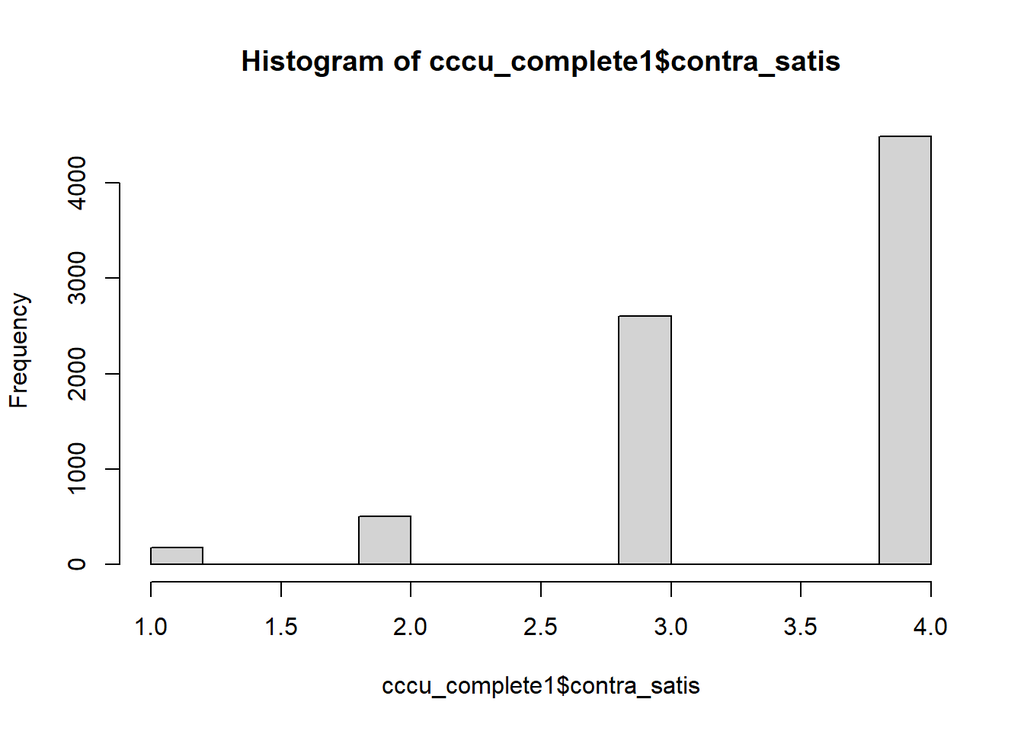

```r
x = cccu_complete1 %>%
  select(hc, Q23D_PILL_r, Q23D_PATCH_r, Q23D_DEPO_r,
         Q23D_IMPLANT_r, Q23D_RING_r,RSAT1_r, RSAT2_r, RSAT3_r, RSAT4_r, RSAT5_r, contra_satis)

hist(cccu_complete1$contra_satis)
```

```r
crosstabs( ~ is.na(contra_satis) + WAVE, data = cccu_complete1)
```

```
##                    WAVE
## is.na(contra_satis)   t1   t2   t3   t4
##               FALSE 3118 2039 1475 1139
##               TRUE  1516 1168  923  703
```

##4.21 Contraceptive Duration -> only duration values for hc users are needed for subanalysis -> we have t1: years & month duration t2-4: last 6 month –> we need to pmax() -> get higher duration value for when women are using a combination –> then combine values from years and month –> then add t1 + t2 usw…

```r
#combine values first bc we only want maximum for combined time
# not e.g. max years for pill and max months for patch
crosstabs( ~ YPILL + WAVE, data = cccu_complete1)
```

```
##       WAVE
## YPILL    t1   t2   t3   t4
##   0     312    0    0    0
##   1     185    0    0    0
##   2     188    0    0    0
##   3     116    0    0    0
##   4     104    0    0    0
##   5     102    0    0    0
##   6      85    0    0    0
##   7      71    0    0    0
##   8      64    0    0    0
##   9      40    0    0    0
##   10     48    0    0    0
##   11     25    0    0    0
##   12     33    0    0    0
##   13      9    0    0    0
##   14     14    0    0    0
##   15     20    0    0    0
##   16      7    0    0    0
##   17      4    0    0    0
##   18      4    0    0    0
##   19      8    0    0    0
##   20      4    0    0    0
##   23      1    0    0    0
##   25      1    0    0    0
##   39      1    0    0    0
##   <NA> 3188 3207 2398 1842
```

```r
crosstabs( ~ MPILL + WAVE, data = cccu_complete1)
```

```
##       WAVE
## MPILL    t1   t2   t3   t4
##   0     672    0    0    0
##   1      82    0    0    0
##   2      92    0    0    0
##   3      88    0    0    0
##   4      73    0    0    0
##   5      77    0    0    0
##   6     149    0    0    0
##   7      37    0    0    0
##   8      62    0    0    0
##   9      46    0    0    0
##   10     38    0    0    0
##   11     30    0    0    0
##   <NA> 3188 3207 2398 1842
```

```r
crosstabs( ~ YPATCH + WAVE, data = cccu_complete1)
```

```
##       WAVE
## YPATCH   t1   t2   t3   t4
##   0       8    0    0    0
##   1       5    0    0    0
##   3       1    0    0    0
##   4       1    0    0    0
##   5       3    0    0    0
##   6       1    0    0    0
##   7       1    0    0    0
##   9       1    0    0    0
##   10      1    0    0    0
##   16      2    0    0    0
##   <NA> 4610 3207 2398 1842
```

```r
crosstabs( ~ MPATCH + WAVE, data = cccu_complete1)
```

```
##       WAVE
## MPATCH   t1   t2   t3   t4
##   0      12    0    0    0
##   1       3    0    0    0
##   2       1    0    0    0
##   3       1    0    0    0
##   4       2    0    0    0
##   6       2    0    0    0
##   7       1    0    0    0
##   9       2    0    0    0
##   <NA> 4610 3207 2398 1842
```

```r
crosstabs( ~ YRING + WAVE, data = cccu_complete1)
```

```
##       WAVE
## YRING    t1   t2   t3   t4
##   0      50    0    0    0
##   1      15    0    0    0
##   2      25    0    0    0
##   3      19    0    0    0
##   4      12    0    0    0
##   5       7    0    0    0
##   6       4    0    0    0
##   7       1    0    0    0
##   8       4    0    0    0
##   9       1    0    0    0
##   10      1    0    0    0
##   12      1    0    0    0
##   <NA> 4494 3207 2398 1842
```

```r
crosstabs( ~ MRING + WAVE, data = cccu_complete1)
```

```
##       WAVE
## MRING    t1   t2   t3   t4
##   0      53    0    0    0
##   1      12    0    0    0
##   2       7    0    0    0
##   3      17    0    0    0
##   4       6    0    0    0
##   5       9    0    0    0
##   6      15    0    0    0
##   7       1    0    0    0
##   8       5    0    0    0
##   9       6    0    0    0
##   10      7    0    0    0
##   11      2    0    0    0
##   <NA> 4494 3207 2398 1842
```

```r
crosstabs( ~ YDEPO + WAVE, data = cccu_complete1)
```

```
##       WAVE
## YDEPO    t1   t2   t3   t4
##   0      61    0    0    0
##   1      30    0    0    0
##   2      22    0    0    0
##   3      24    0    0    0
##   4      17    0    0    0
##   5       7    0    0    0
##   6       5    0    0    0
##   7       3    0    0    0
##   8       4    0    0    0
##   9       3    0    0    0
##   10      6    0    0    0
##   11      1    0    0    0
##   12      2    0    0    0
##   14      1    0    0    0
##   15      3    0    0    0
##   17      1    0    0    0
##   19      1    0    0    0
##   32      1    0    0    0
##   <NA> 4442 3207 2398 1842
```

```r
crosstabs( ~ MDEPO + WAVE, data = cccu_complete1)
```

```
##       WAVE
## MDEPO    t1   t2   t3   t4
##   0      82    0    0    0
##   1      17    0    0    0
##   2      14    0    0    0
##   3      21    0    0    0
##   4       9    0    0    0
##   5      10    0    0    0
##   6      13    0    0    0
##   7       6    0    0    0
##   8       4    0    0    0
##   9       7    0    0    0
##   10      2    0    0    0
##   11      7    0    0    0
##   <NA> 4442 3207 2398 1842
```

```r
crosstabs( ~ YIMPLANT + WAVE, data = cccu_complete1)
```

```
##         WAVE
## YIMPLANT   t1   t2   t3   t4
##     0      29    0    0    0
##     1      25    0    0    0
##     2      19    0    0    0
##     3       3    0    0    0
##     4       2    0    0    0
##     5       3    0    0    0
##     <NA> 4553 3207 2398 1842
```

```r
crosstabs( ~ MIMPLANT + WAVE, data = cccu_complete1)
```

```
##         WAVE
## MIMPLANT   t1   t2   t3   t4
##     0      12    0    0    0
##     1       6    0    0    0
##     2       7    0    0    0
##     3       5    0    0    0
##     4       8    0    0    0
##     5       8    0    0    0
##     6       9    0    0    0
##     7       4    0    0    0
##     8       7    0    0    0
##     9       5    0    0    0
##     10      2    0    0    0
##     11      8    0    0    0
##     <NA> 4553 3207 2398 1842
```

```r
cccu_complete1 <- cccu_complete1 %>%
  mutate(
    hc_dur_pill = YPILL + MPILL,
    hc_dur_patch = YPATCH + MPATCH,
    hc_dur_ring = YRING + MRING,
    hc_dur_depo = YDEPO + MDEPO,
    hc_dur_implant = YIMPLANT + MIMPLANT
  )
# for the simulated data this is a problem, bc if Y or M are missing, hc_dur is missing as well
# this is not a problem for real data, bc !is.na(Y) <--> !is.na(M)

# find longest time
cccu_complete1 <- cccu_complete1 %>%
  mutate(
    hc_dur = pmax(
      hc_dur_pill,
      hc_dur_patch,
      hc_dur_ring,
      hc_dur_depo,
      hc_dur_implant,
      na.rm = TRUE
    )
  )

# distribution at t1
table(cccu_complete1$hc_dur)
```

```
##
##   0   1   2   3   4   5   6   7   8   9  10  11  12  13  14  15  16  17  18  19
##  31 144 185 171 144 147 169 127 136 122 126  90  75  42  31  36  18  10  11   8
##  20  21  22  23  25  26  29  32  40
##   9   2   2   1   3   1   1   1   1
```

```r
# missings:
table(is.na(cccu_complete1$hc_dur)) # a lot of missing bc of simulated data
```

```
##
## FALSE  TRUE
##  1844 10237
```

```r
# check this for real data (shouldnt be that much missing!)

#duration time for t2-t4

crosstabs( ~ Q23A_PILL + WAVE, data = cccu_complete1)
```

```
##               WAVE
## Q23A_PILL       t1  t2  t3  t4
##   (-1) Refused   0   1   2   0
##   (1) 0          0   7   8   7
##   (2) 1          0  29  21  22
##   (3) 2          0  29  21   9
##   (4) 3          0  29  20  22
##   (5) 4          0  35  23  12
##   (6) 5          0  31  21  17
##   (7) 6          0 813 608 476
```

```r
crosstabs( ~ Q23A_PATCH + WAVE, data = cccu_complete1)
```

```
##               WAVE
## Q23A_PATCH     t1 t2 t3 t4
##   (-1) Refused  0  0  0  0
##   (1) 0         0  2  0  0
##   (2) 1         0  0  0  0
##   (3) 2         0  1  2  1
##   (4) 3         0  1  1  1
##   (5) 4         0  0  0  0
##   (6) 5         0  2  1  1
##   (7) 6         0  9  2  3
```

```r
crosstabs( ~ Q23A_RING + WAVE, data = cccu_complete1)
```

```
##               WAVE
## Q23A_RING      t1 t2 t3 t4
##   (-1) Refused  0  1  0  0
##   (1) 0         0  1  0  1
##   (2) 1         0  2  3  1
##   (3) 2         0  4  2  2
##   (4) 3         0  2  3  4
##   (5) 4         0  6  4  0
##   (6) 5         0  2  1  2
##   (7) 6         0 76 44 32
```

```r
crosstabs( ~ Q23A_DEPO + WAVE, data = cccu_complete1)
```

```
##               WAVE
## Q23A_DEPO      t1 t2 t3 t4
##   (-1) Refused  0  2  0  0
##   (1) 0         0  2  2  1
##   (2) 1         0  6  2  6
##   (3) 2         0 35 29 13
##   (4) 3         0  5  7  4
##   (5) 4         0  2  2  1
##   (6) 5         0  2  2  0
##   (7) 6         0 56 33 23
```

```r
crosstabs( ~ Q23A_IMPLANT + WAVE, data = cccu_complete1)
```

```
##               WAVE
## Q23A_IMPLANT   t1 t2 t3 t4
##   (-1) Refused  0  1  0  0
##   (1) 0         0  1  1  0
##   (2) 1         0  4  2  0
##   (3) 2         0  0  3  3
##   (4) 3         0  1  1  1
##   (5) 4         0  1  2  2
##   (6) 5         0  2  1  0
##   (7) 6         0 40 28 25
```

```r
# recode duration time for t2 - t4 into numeric values
cccu_complete1 = cccu_complete1 %>%
  mutate(Q23A_PILL = ifelse(Q23A_PILL %contains% "(1)", 0,
                              ifelse(Q23A_PILL %contains% "(2)", 1,
                                      ifelse(Q23A_PILL %contains% "(3)", 2,
                      ifelse(Q23A_PILL %contains% "(4)", 3,
                             ifelse(Q23A_PILL %contains% "(5)", 4,
                                    ifelse(Q23A_PILL %contains% "(6)", 5,
                                           ifelse(Q23A_PILL %contains% "(7)", 6,                                       ifelse(Q23A_PILL %contains% "(-1)", NA, NA)))))))),
         Q23A_PATCH = ifelse(Q23A_PATCH %contains% "(1)", 0,
                   ifelse(Q23A_PATCH %contains% "(2)", 1,
                          ifelse(Q23A_PATCH %contains% "(3)", 2,
                                 ifelse(Q23A_PATCH %contains% "(4)", 3,
                                        ifelse(Q23A_PATCH %contains% "(5)", 4,
                                               ifelse(Q23A_PATCH %contains% "(6)", 5,
                                                      ifelse(Q23A_PATCH %contains% "(7)", 6,                                       ifelse(Q23A_PATCH %contains% "(-1)", NA, NA)))))))),
         Q23A_RING = ifelse(Q23A_RING %contains% "(1)", 0,
                   ifelse(Q23A_RING %contains% "(2)", 1,
                          ifelse(Q23A_RING %contains% "(3)", 2,
                                 ifelse(Q23A_RING %contains% "(4)", 3,
                                        ifelse(Q23A_RING %contains% "(5)", 4,
                                               ifelse(Q23A_RING %contains% "(6)", 5,
                                                      ifelse(Q23A_RING %contains% "(7)", 6,                                       ifelse(Q23A_RING %contains% "(-1)", NA, NA)))))))),
         Q23A_DEPO = ifelse(Q23A_DEPO %contains% "(1)", 0,
                   ifelse(Q23A_DEPO %contains% "(2)", 1,
                          ifelse(Q23A_DEPO %contains% "(3)", 2,
                                 ifelse(Q23A_DEPO %contains% "(4)", 3,
                                        ifelse(Q23A_DEPO %contains% "(5)", 4,
                                               ifelse(Q23A_DEPO %contains% "(6)", 5,
                                                      ifelse(Q23A_DEPO %contains% "(7)", 6,                                       ifelse(Q23A_DEPO %contains% "(-1)", NA, NA)))))))),
         Q23A_IMPLANT = ifelse(Q23A_IMPLANT %contains% "(1)", 0,
                   ifelse(Q23A_IMPLANT %contains% "(2)", 1,
                          ifelse(Q23A_IMPLANT %contains% "(3)", 2,
                                 ifelse(Q23A_IMPLANT %contains% "(4)", 3,
                                        ifelse(Q23A_IMPLANT %contains% "(5)", 4,
                                               ifelse(Q23A_IMPLANT %contains% "(6)", 5,
                                                      ifelse(Q23A_IMPLANT %contains% "(7)", 6,                                       ifelse(Q23A_IMPLANT %contains% "(-1)", NA, NA)))))))))


# find values based on t2-t4
cccu_complete1 <- cccu_complete1 %>%
  mutate(hc_dur_add = pmax(Q23A_PILL, Q23A_PATCH, Q23A_RING, Q23A_DEPO, Q23A_IMPLANT,
                            na.rm = TRUE))

# distribution
table(cccu_complete1$hc_dur_add)
```

```
##
##    0    1    2    3    4    5    6
##   25   93  147  102   90   85 2267
```

```r
# missingness
table(is.na(cccu_complete1$hc_dur_add)) # a lot of missing bc of simulated data
```

```
##
## FALSE  TRUE
##  2809  9272
```

```r
# now calculate total duration values t1 + t2-4
cccu_complete1 = cccu_complete1 %>%
  group_by(CASEID) %>%
  mutate(hc_prev = lag(hc),
         hc_dur_prev = lag(hc_dur)) %>%
  ungroup() %>%
  mutate(hc_dur_1 = hc_dur,
         hc_dur_2 = ifelse(WAVE == "t2" & hc == hc_prev,
                           hc_dur_prev + 6,
                           ifelse(WAVE == "t2" & hc == "hc" & hc_prev == "non_hc",
                                  hc_dur_add,
                                  NA))) %>%
  group_by(CASEID) %>%
  mutate(hc_dur_prev = lag(hc_dur_2)) %>%
  ungroup() %>%
  mutate(hc_dur_3 = ifelse(WAVE == "t3" & hc == hc_prev,
                           hc_dur_prev + 6,
                           ifelse(WAVE == "t3" & hc == "hc" & hc_prev == "non_hc",
                                  hc_dur_add,
                                  NA))) %>%
  group_by(CASEID) %>%
  mutate(hc_dur_prev = lag(hc_dur_3)) %>%
  ungroup() %>%
  mutate(hc_dur_4 = ifelse(WAVE == "t4" & hc == hc_prev,
                           hc_dur_prev + 6,
                           ifelse(WAVE == "t4" & hc == "hc" & hc_prev == "non_hc",
                                  hc_dur_add,
                                  NA))) %>%
  select(-hc_prev, -hc_dur_prev)

table(cccu_complete1$hc_dur_1)
```

```
##
##   0   1   2   3   4   5   6   7   8   9  10  11  12  13  14  15  16  17  18  19
##  31 144 185 171 144 147 169 127 136 122 126  90  75  42  31  36  18  10  11   8
##  20  21  22  23  25  26  29  32  40
##   9   2   2   1   3   1   1   1   1
```

```r
table(cccu_complete1$hc_dur_2)
```

```
##
##   0   1   2   3   4   5   6   7   8   9  10  11  12  13  14  15  16  17  18  19
##   7  25  18  23  21  11  53  68 100  90  79  86  95  75  91  81  79  49  46  26
##  20  21  22  23  24  25  26  27  28  29  31  32  35  38
##  22  26  11   8   7   6   7   1   1   1   2   1   1   1
```

```r
table(cccu_complete1$hc_dur_3)
```

```
##
##  0  1  2  3  4  5  6  7  8  9 10 11 12 13 14 15 16 17 18 19 20 21 22 23 24 25
##  4 18 13 15 14  4 29 10  8 10 16  4 26 40 56 56 55 61 73 49 64 51 58 40 32 15
## 26 27 28 29 30 31 32 33 34 35 37 38 41
## 13 17  6  3  6  2  4  1  1  1  2  1  1
```

```r
table(cccu_complete1$hc_dur_4)
```

```
##
##  0  1  2  3  4  5  6  7  8  9 10 11 12 13 14 15 16 18 19 20 21 22 23 24 25 26
##  5 17 11 19  2  7 25 11  9  8  8  3 11  3  5  4  6 18 27 33 34 40 36 53 32 52
## 27 28 29 30 31 32 33 34 35 36 37 38 40 41 43
## 40 47 28 24 13 10 13  6  3  4  2  4  1  1  1
```

```r
#combine waves
cccu_complete1 = cccu_complete1 %>%
  mutate(hc_dur = ifelse(!is.na(hc_dur_1), hc_dur_1,
                         ifelse(!is.na(hc_dur_2), hc_dur_2,
                                ifelse(!is.na(hc_dur_3), hc_dur_3,
                                       ifelse(!is.na(hc_dur_4), hc_dur_4, NA)))))

table(cccu_complete1$hc_dur)
```

```
##
##   0   1   2   3   4   5   6   7   8   9  10  11  12  13  14  15  16  17  18  19
##  47 204 227 228 181 169 276 216 253 230 229 183 207 160 183 177 158 120 148 110
##  20  21  22  23  24  25  26  27  28  29  30  31  32  33  34  35  36  37  38  40
## 128 113 111  85  92  56  73  58  54  33  30  17  16  14   7   5   4   4   6   2
##  41  43
##   2   1
```

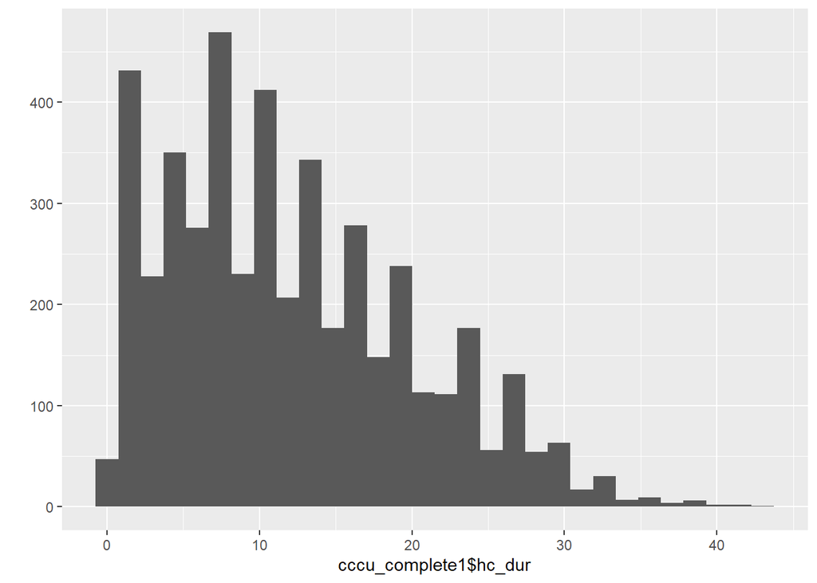

```r
qplot(cccu_complete1$hc_dur)
```

##4.22 switch

```r
cccu_complete1 <- cccu_complete1 %>%
  group_by(CASEID) %>%
  mutate(hc_next = lead(hc),
         switch = case_when(hc == hc_next ~ 0,
                            hc != hc_next ~ 1)) %>%
  ungroup()

cccu_complete1 %>% select(CASEID, WAVE, hc, hc_next, switch) %>% View()

cccu_complete1 %>%
  filter(WAVE != "t4") %>%
  select(switch) %>%
  is.na() %>%
  table()
```

```
## .
## FALSE  TRUE
##  7447  2792
```

```r
table(is.na(cccu_complete1$switch))
```

```
##
## FALSE  TRUE
##  7447  4634
```

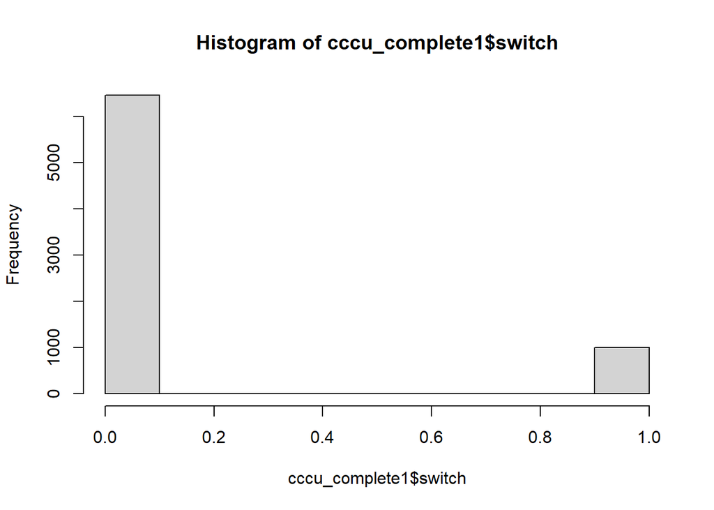

```r
hist(cccu_complete1$switch)
```

#final data wrangling steps (for models) ##hc and sex_freq

```r
cccu_complete1 <- cccu_complete1 %>%
  mutate(hc = factor(as.character(hc),
                     levels = c("hc", "non_hc", "IUD&non_hc"),
                     labels = c("hc", "non_hc", "IUD&non_hc")),
         sex_freq = factor(sex_freq,
                           levels = c("No sex or once", "2-5 times", "6-10 times", "11 or more times"),
                           labels = c("No sex or once", "2-5 times", "6-10 times", "11 or more times")))
```

#5. Saving Data

```r
save(cccu_complete1,file = "cccu_complete1.RData")

load("cccu_complete1.RData")
```